# Ensemble Techniques Project

## Submitted by Utathya Ghosh

### Batch - AIML Online Jan 21-A

# TOTAL SCORE - 60

DOMAIN: Telecom

CONTEXT: A telecom company wants to use their historical customer data to predict behaviour to retain customers. You can analyse all relevant customer data and develop focused customer retention programs.

DATA DESCRIPTION: Each row represents a customer, each column contains customer’s attributes described on the column Metadata. The data set includes information about:

1. Customers who left within the last month – the column is called Churn
2. Services that each customer has signed up for – phone, multiple lines, internet, online security, online backup, device protection, tech support, and streaming TV and movies
3. Customer account information – how long they’ve been a customer, contract, payment method, paperless billing, monthly charges, and total charges
4. Demographic info about customers – gender, age range, and if they have partners and dependents

PROJECT OBJECTIVE: Build a model that will help to identify the potential customers who have a higher probability to churn. This help the company to understand the pinpoints and patterns of customer churn and will increase the focus on strategising customer retention.

###### Please note that due to multiple grid search in the code, running the entire notebook will take close to an hour, or more depending on the system. I thought about adding if conditions on certain steps in case the auditor wishes to skip the Grid Search steps but that caused some cosmetic issues. Hence I suggest that the auditor jump Grid Search steps on their own in case they want to run the entire notebook and also do it fast.

```python
import pandas as pd
import numpy as np
import os
import time
from matplotlib import pyplot as plt
import seaborn as sns
sns.set(color_codes=True) # adds a nice background to the graphs
%matplotlib inline
from scipy.stats import ttest_ind, shapiro, chi2_contingency
from sklearn.model_selection import train_test_split
from imblearn.over_sampling import SMOTE
from sklearn import preprocessing
from sklearn.ensemble import RandomForestClassifier
from sklearn.model_selection import GridSearchCV
from sklearn.tree import DecisionTreeClassifier
from sklearn.ensemble import AdaBoostClassifier
from sklearn.ensemble import GradientBoostingClassifier
from xgboost import XGBClassifier
from sklearn.ensemble import BaggingClassifier
from sklearn.metrics import precision_score, recall_score, roc_auc_score, confusion_matrix
import pickle
import tkinter as tk
from tkinter import *
from tkinter import ttk
import math
```

#### 1. Import and warehouse data: [ Score: 5 point ]

###### • Import all the given datasets from MYSQL server. Explore shape and size.

```python
# Reading the csv file into dataframe

# Error handling for missing TelcomCustomer_Churn dataset csv
# Running a loop till correct file has been found
while(True):
    try:
        # Reading the desired dataset into desired df_ tagged variable
        df_tel1 = pd.read_csv("TelcomCustomer-Churn_1.csv")
        # Leaving loop if file found
        break
    except OSError as e:

        # Provide instructions if file not found
        file_path = os.path.join(os.path.abspath(''))
        print("Please place the file named <TelcomCustomer-Churn_1.csv> at the path", file_path)
        # Waiting for user input to check again, Actual verification of what user has inputted is inconsequential
        input("System waits: Have you placed the correct files in path? (Input 'Y' for Yes)")

# Error handling for missing TelcomCustomer_Churn dataset csv
# Running a loop till correct file has been found
while(True):
    try:
        # Reading the desired dataset into desired df_ tagged variable
        df_tel2 = pd.read_csv("TelcomCustomer-Churn_2.csv")
        # Leaving loop if file found
        break
    except OSError as e:

        # Provide instructions if file not found
        file_path = os.path.join(os.path.abspath(''))
        print("Please place the file named <TelcomCustomer-Churn_2.csv> at the path", file_path)
        # Waiting for user input to check again, Actual verification of what user has inputted is inconsequential
        input("System waits: Have you placed the correct files in path? (Input 'Y' for Yes)")
```

```python
# Displaying the shape and size of all dataframes created

# Adding a wait time of 10 seconds for vars dictionary to be updated


for t in range(5,30,5):
# Running a loop through all variables
    try:
        for name in vars().keys():
            # Entry into loop allowed only for dataframes created based on our naming conventions
            if name[:3] == "df_":
                # Printing Required informations
                print(name, ":-")
                print("Shape : ", eval(name).shape)
                print("Size : ", eval(name).size)
                # Extra print added for cosmetic reasons
                print()
        break
    except RuntimeError as e:
        time.sleep(t)
        continue
```

[output not shown]

###### • Merge all datasets onto one and explore final shape and size.

```python
# Merging all datsets into one master dataset
df_tel = df_tel1.merge(df_tel2, left_index=True, right_index=True)

# Displaying master dataset shape and size
print("Shape of Combined dataset: ", df_tel.shape)
print("Size of Combined dataset: ", df_tel.size)
```

```
Shape of Combined dataset:  (7043, 21)
Size of Combined dataset:  147903
```

#### 2. Data cleansing: [ Score: 10 point ]

###### • Missing value treatment

```python
# Displaying the column based data information
df_tel.info()
```

```
<class 'pandas.core.frame.DataFrame'>
RangeIndex: 7043 entries, 0 to 7042
Data columns (total 21 columns):
 #   Column            Non-Null Count  Dtype
---  ------            --------------  -----
 0   customerID        7043 non-null   object
 1   gender            7043 non-null   object
 2   SeniorCitizen     7043 non-null   int64
 3   Partner           7043 non-null   object
 4   Dependents        7043 non-null   object
 5   tenure            7043 non-null   int64
 6   PhoneService      7043 non-null   object
 7   MultipleLines     7043 non-null   object
 8   InternetService   7043 non-null   object
 9   OnlineSecurity    7043 non-null   object
 10  OnlineBackup      7043 non-null   object
 11  DeviceProtection  7043 non-null   object
 12  TechSupport       7043 non-null   object
 13  StreamingTV       7043 non-null   object
 14  StreamingMovies   7043 non-null   object
 15  Contract          7043 non-null   object
 16  PaperlessBilling  7043 non-null   object
 17  PaymentMethod     7043 non-null   object
 18  MonthlyCharges    7043 non-null   float64
 19  TotalCharges      7043 non-null   object
 20  Churn             7043 non-null   object
dtypes: float64(1), int64(2), object(18)
memory usage: 1.1+ MB
```

```python
# Checking the frequency of values in an object with a high number of unique values
np.unique(df_tel['TotalCharges'], return_counts=True)
```

```
(array([' ', '100.2', '100.25', ..., '999.45', '999.8', '999.9'],
       dtype=object),
 array([11,  1,  1, ...,  1,  1,  1], dtype=int64))
```

###### There does not seem to be any obvious null values, but TotalCharges column has some rows with no information, this can be considered null. For a continuous variable, we will consider them as 0.

###### • Convert categorical attributes to continuous using relevant functional knowledge

```python
# Checking the frequency of values of an integer type with very few unique values
np.unique(df_tel['SeniorCitizen'], return_counts=True)
```

```
(array([0, 1], dtype=int64), array([5901, 1142], dtype=int64))
```

###### Total Charges and SeniorCitizen both have been incorrectly tagged as a datatype which it is actually not.

###### • Drop attribute/s if required using relevant functional knowledge

```python
# Checking the frequency of values of a object type which is not numeric but also has too many unique values.
np.unique(df_tel['customerID'], return_counts=True)
```

```
(array(['0002-ORFBO', '0003-MKNFE', '0004-TLHLJ', ..., '9992-UJOEL',
        '9993-LHIEB', '9995-HOTOH'], dtype=object),
 array([1, 1, 1, ..., 1, 1, 1], dtype=int64))
```

###### customerID seems to be unique for every record, which means it is similar to the index and hence redundant and without meaningful information.

###### • Automate all the above steps

```python
# Automating the Data Cleaning section

# Loop through all columns
for col in df_tel.columns:
    # Display column name
    print()
    print(col)
    # Display whether it has null values
    print("Null :", "True" if sum(df_tel.loc[:, col].isnull()) else "False")

    # Check if column is currently assigned to int or float
    if df_tel.loc[:, col].dtype in ['int64', 'float64']:
        # Display the fact that the column is numeric
        print("Numeric assigned : True")

        # Check if column has a very few unique values
        if len(np.unique(df_tel.loc[:, col])) < 10:
            # Display the fact that the column is categoric
            print("Numeric actually: False")

            # Since Assigned datatype and the condition of that datatype do not match hence change data type to object
            df_tel.loc[:, col] = df_tel.loc[:, col].astype('object', errors='ignore')
            print("Column datatype has been changed to object type")

        # On condition that the column has a more than 10 unique values
        else:
            # Display the fact that the column is Numeric
            print("Numeric actually: True")
        # Display that the column is useful at first check
        print("Values are continous and hence useful")

    # On condition that the column is not int or float
    else:
        # Display the fact that the column is considered Categorical
        print("Numeric assigned : False")

        # Check if the categorical column is unique for every record
        if len(df_tel.iloc[:, 0].unique()) == df_tel.shape[0]:
            # Display the condition that the column is actually categorical
            print("Numeric actually: False")

            # Drop the column since every row is different from each other and it is categorical, hence useless
            df_tel.drop(col, inplace=True, axis=1)
            print("Column has been dropped since it unique for every value and hence useless")

        # Check if the categorical column has more than 100 different unique values
        elif len(np.unique(df_tel.loc[:, col])) > 100:

            # Display the fact that test has confirmed that the column is actually numeric
            print("Numeric actually: True")

            # Since Assigned datatype and the condition of that datatype do not match hence change data type to float64
            # Convert the highest frequency value to 0.0
            val = np.unique(df_tel.loc[:, col])[np.unique(df_tel.loc[:, col], return_counts=True)[1].argmax()]
            df_tel.loc[df_tel.loc[:, col] == val, col] = 0.0

            # Now the column is ready to converted to float datatype
            df_tel.loc[:, col] = df_tel.loc[:, col].astype('float64', errors='raise')
            print("Column datatype has been changed to float64 type")

        # On condition that the categorical variable has few unique values
        else:
            # Display the fact that on test we think the column is categorical and useful
            print("Numeric actually: False")
            print("Values are categorical and useful")
```

```
customerID
Null : False
Numeric assigned : False
Numeric actually: False
Column has been dropped since it unique for every value and hence useless

gender
Null : False
Numeric assigned : False
Numeric actually: False
Values are categorical and useful

SeniorCitizen
Null : False
Numeric assigned : True
Numeric actually: False
Column datatype has been changed to object type
Values are continous and hence useful

Partner
Null : False
Numeric assigned : False
Numeric actually: False
Values are categorical and useful

Dependents
Null : False
Numeric assigned : False
Numeric actually: False
Values are categorical and useful

tenure
Null : False
Numeric assigned : True
Numeric actually: True
Values are continous and hence useful

PhoneService
Null : False
Numeric assigned : False
```

[output cut: 71 more lines]

```
Numeric assigned : True
Numeric actually: True
Values are continous and hence useful

TotalCharges
Null : False
Numeric assigned : False
Numeric actually: True
Column datatype has been changed to float64 type

Churn
Null : False
Numeric assigned : False
Numeric actually: False
Values are categorical and useful
```

```python
# Displaying the data information after the cleaning process
df_tel.info()
```

```
<class 'pandas.core.frame.DataFrame'>
RangeIndex: 7043 entries, 0 to 7042
Data columns (total 20 columns):
 #   Column            Non-Null Count  Dtype
---  ------            --------------  -----
 0   gender            7043 non-null   object
 1   SeniorCitizen     7043 non-null   object
 2   Partner           7043 non-null   object
 3   Dependents        7043 non-null   object
 4   tenure            7043 non-null   int64
 5   PhoneService      7043 non-null   object
 6   MultipleLines     7043 non-null   object
 7   InternetService   7043 non-null   object
 8   OnlineSecurity    7043 non-null   object
 9   OnlineBackup      7043 non-null   object
 10  DeviceProtection  7043 non-null   object
 11  TechSupport       7043 non-null   object
 12  StreamingTV       7043 non-null   object
 13  StreamingMovies   7043 non-null   object
 14  Contract          7043 non-null   object
 15  PaperlessBilling  7043 non-null   object
 16  PaymentMethod     7043 non-null   object
 17  MonthlyCharges    7043 non-null   float64
 18  TotalCharges      7043 non-null   float64
 19  Churn             7043 non-null   object
dtypes: float64(2), int64(1), object(17)
memory usage: 1.1+ MB
```

#### 3. Data analysis & visualisation: [ Score: 10 point ]

###### • Perform detailed statistical analysis on the data.

###### For All records where Churn is Yes (Our Positive or desired category, these are the class we are looking for as an objective)

```python
# Look through basic stats on the dataset for Asset clients
df_tel[df_tel["Churn"] == "Yes"].describe(include='all')
```

|  | gender | SeniorCitizen | Partner | Dependents | tenure | PhoneService | MultipleLines | InternetService | OnlineSecurity | OnlineBackup | DeviceProtection | TechSupport | StreamingTV | StreamingMovies | Contract | PaperlessBilling | PaymentMethod | MonthlyCharges | TotalCharges | Churn |
| --- | --- | --- | --- | --- | --- | --- | --- | --- | --- | --- | --- | --- | --- | --- | --- | --- | --- | --- | --- | --- |
| count | 1869 | 1869.0 | 1869 | 1869 | 1869.000000 | 1869 | 1869 | 1869 | 1869 | 1869 | 1869 | 1869 | 1869 | 1869 | 1869 | 1869 | 1869 | 1869.000000 | 1869.000000 | 1869 |
| unique | 2 | 2.0 | 2 | 2 | NaN | 2 | 3 | 3 | 3 | 3 | 3 | 3 | 3 | 3 | 3 | 2 | 4 | NaN | NaN | 1 |
| top | Female | 0.0 | No | No | NaN | Yes | Yes | Fiber optic | No | No | No | No | No | No | Month-to-month | Yes | Electronic check | NaN | NaN | Yes |
| freq | 939 | 1393.0 | 1200 | 1543 | NaN | 1699 | 850 | 1297 | 1461 | 1233 | 1211 | 1446 | 942 | 938 | 1655 | 1400 | 1071 | NaN | NaN | 1869 |
| mean | NaN | NaN | NaN | NaN | 17.979133 | NaN | NaN | NaN | NaN | NaN | NaN | NaN | NaN | NaN | NaN | NaN | NaN | 74.441332 | 1531.796094 | NaN |
| std | NaN | NaN | NaN | NaN | 19.531123 | NaN | NaN | NaN | NaN | NaN | NaN | NaN | NaN | NaN | NaN | NaN | NaN | 24.666053 | 1890.822994 | NaN |
| min | NaN | NaN | NaN | NaN | 1.000000 | NaN | NaN | NaN | NaN | NaN | NaN | NaN | NaN | NaN | NaN | NaN | NaN | 18.850000 | 18.850000 | NaN |
| 25% | NaN | NaN | NaN | NaN | 2.000000 | NaN | NaN | NaN | NaN | NaN | NaN | NaN | NaN | NaN | NaN | NaN | NaN | 56.150000 | 134.500000 | NaN |
| 50% | NaN | NaN | NaN | NaN | 10.000000 | NaN | NaN | NaN | NaN | NaN | NaN | NaN | NaN | NaN | NaN | NaN | NaN | 79.650000 | 703.550000 | NaN |
| 75% | NaN | NaN | NaN | NaN | 29.000000 | NaN | NaN | NaN | NaN | NaN | NaN | NaN | NaN | NaN | NaN | NaN | NaN | 94.200000 | 2331.300000 | NaN |
| max | NaN | NaN | NaN | NaN | 72.000000 | NaN | NaN | NaN | NaN | NaN | NaN | NaN | NaN | NaN | NaN | NaN | NaN | 118.350000 | 8684.800000 | NaN |

###### For All records where Churn is No

```python
# Look through basic stats on the dataset for other clients
df_tel[df_tel["Churn"] != "Yes"].describe(include='all')
```

|  | gender | SeniorCitizen | Partner | Dependents | tenure | PhoneService | MultipleLines | InternetService | OnlineSecurity | OnlineBackup | DeviceProtection | TechSupport | StreamingTV | StreamingMovies | Contract | PaperlessBilling | PaymentMethod | MonthlyCharges | TotalCharges | Churn |
| --- | --- | --- | --- | --- | --- | --- | --- | --- | --- | --- | --- | --- | --- | --- | --- | --- | --- | --- | --- | --- |
| count | 5174 | 5174.0 | 5174 | 5174 | 5174.000000 | 5174 | 5174 | 5174 | 5174 | 5174 | 5174 | 5174 | 5174 | 5174 | 5174 | 5174 | 5174 | 5174.000000 | 5174.000000 | 5174 |
| unique | 2 | 2.0 | 2 | 2 | NaN | 2 | 3 | 3 | 3 | 3 | 3 | 3 | 3 | 3 | 3 | 2 | 4 | NaN | NaN | 1 |
| top | Male | 0.0 | Yes | No | NaN | Yes | No | DSL | No | Yes | No | No | Yes | Yes | Month-to-month | Yes | Mailed check | NaN | NaN | No |
| freq | 2625 | 4508.0 | 2733 | 3390 | NaN | 4662 | 2541 | 1962 | 2037 | 1906 | 1884 | 2027 | 1893 | 1914 | 2220 | 2771 | 1304 | NaN | NaN | 5174 |
| mean | NaN | NaN | NaN | NaN | 37.569965 | NaN | NaN | NaN | NaN | NaN | NaN | NaN | NaN | NaN | NaN | NaN | NaN | 61.265124 | 2549.911442 | NaN |
| std | NaN | NaN | NaN | NaN | 24.113777 | NaN | NaN | NaN | NaN | NaN | NaN | NaN | NaN | NaN | NaN | NaN | NaN | 31.092648 | 2329.954215 | NaN |
| min | NaN | NaN | NaN | NaN | 0.000000 | NaN | NaN | NaN | NaN | NaN | NaN | NaN | NaN | NaN | NaN | NaN | NaN | 18.250000 | 0.000000 | NaN |
| 25% | NaN | NaN | NaN | NaN | 15.000000 | NaN | NaN | NaN | NaN | NaN | NaN | NaN | NaN | NaN | NaN | NaN | NaN | 25.100000 | 572.900000 | NaN |
| 50% | NaN | NaN | NaN | NaN | 38.000000 | NaN | NaN | NaN | NaN | NaN | NaN | NaN | NaN | NaN | NaN | NaN | NaN | 64.425000 | 1679.525000 | NaN |
| 75% | NaN | NaN | NaN | NaN | 61.000000 | NaN | NaN | NaN | NaN | NaN | NaN | NaN | NaN | NaN | NaN | NaN | NaN | 88.400000 | 4262.850000 | NaN |
| max | NaN | NaN | NaN | NaN | 72.000000 | NaN | NaN | NaN | NaN | NaN | NaN | NaN | NaN | NaN | NaN | NaN | NaN | 118.750000 | 8672.450000 | NaN |

###### There are some interesting points difference in the statistics from above. Let us verify whether these differences are significant

###### Before jumping into the test let us set our Null Hypothesis and Alternate Hypothesis.

###### Ho is μ(Churn = "Yes") = μ(Churn = "No")

###### Ha is μ(Churn = "Yes") ≠ μ(Churn = "No")

```python
# Creating a function which will return required outputs after performing welch_ttest
def welch_ttest(x, y):
    ## Welch-Satterthwaite Degrees of Freedom ##
    dof = (x.var()/x.size + y.var()/y.size)**2 / ((x.var()/x.size)**2 / (x.size-1) + (y.var()/y.size)**2 / (y.size-1))

    # Welch's Test
    t, p = ttest_ind(x, y, equal_var = False)

    # Displaying the results found
    print("\n",
          f"Welch's t-test= {t:.4f}", "\n",
          f"p-value = {p:.4f}", "\n",
          f"Welch-Satterthwaite Degrees of Freedom= {dof:.4f}")
```

```python
# Performing Welch's t test on Churn(Yes) and others groups for all continous independent variables
# Running a for loop to extract each continous attribute name individually
for col in list(df_tel.select_dtypes(include=['int64','float64']).columns):
    # Creating a 2 groups based on Dependent variable labels Normal and Abnormal (Type_H and Type_S)
    group1 = df_tel[col][df_tel["Churn"]=="Yes"]
    group2 = df_tel[col][df_tel["Churn"]!="Yes"]

    # Printing newline for cosmetic purposes
    print("\n", col)

    # If Shapiro test clears both groups (Confidence of 95%) then perform welch test else display appropriate message
    if (shapiro(group1)[1]<0.05) and (shapiro(group2)[1]<0.05):
        welch_ttest(group1, group2)
    else:
        print("\n At least one of the classes (Yes or No) is not normally distributed")
```

```
 tenure

 Welch's t-test= -34.8238
 p-value = 0.0000
 Welch-Satterthwaite Degrees of Freedom= 4048.2876

 MonthlyCharges

 Welch's t-test= 18.4075
 p-value = 0.0000
 Welch-Satterthwaite Degrees of Freedom= 4135.7950

 TotalCharges

 Welch's t-test= -18.7066
 p-value = 0.0000
 Welch-Satterthwaite Degrees of Freedom= 4040.2532
```

###### As expected the difference in mean is significant for all continous variables. It was expected since we have a reasonably high number of data points and so we are closer to population, and we can by eye balling see a difference in mean for all variables.

###### Now let us look at correlation between all continous independent variables. If there is a high correlation we may decide to drop one of the variables.

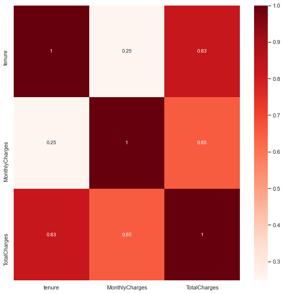

```python
# Displaying the correlation map
f, ax = plt.subplots(figsize=(10, 10))
sns.heatmap(df_tel.select_dtypes(include=['int64','float64']).corr(), annot=True, cmap='Reds', ax=ax)
plt.show()
```

###### Inference 1: tenure and MonthlyCharges have a low correlation, which signifies these two variables are holding seperate information and could be used to explain TotalCharges.

```python
for col in list(df_tel.select_dtypes(include=['object']).columns)[:-1]:
    crosstab = pd.crosstab(df_tel['Churn'], df_tel[col])
    chi, p_value, dof, expected = chi2_contingency(crosstab)
    print(col, "p - ", p_value)
    if p_value < 0.05:  # Setting our significance level at 5%
        print('{} Rejecting Null Hypothesis. \n There is significant difference in {} Feature for different category of target variable(Churn)'.format('\033[1m', col))
    else:
        print('{} Fail to Reject Null Hypothesis.\n There is no significant difference in {} Feature for different category of target variable(Churn)'.format('\033[1m', col))
    print('\n')
```

```
gender p -  0.48657873605618596
 Fail to Reject Null Hypothesis.
 There is no significant difference in gender Feature for different category of target variable(Churn)


SeniorCitizen p -  1.510066805092378e-36
 Rejecting Null Hypothesis.
 There is significant difference in SeniorCitizen Feature for different category of target variable(Churn)


Partner p -  2.1399113440759935e-36
 Rejecting Null Hypothesis.
 There is significant difference in Partner Feature for different category of target variable(Churn)


Dependents p -  4.9249216612154196e-43
 Rejecting Null Hypothesis.
 There is significant difference in Dependents Feature for different category of target variable(Churn)


PhoneService p -  0.3387825358066928
 Fail to Reject Null Hypothesis.
 There is no significant difference in PhoneService Feature for different category of target variable(Churn)


MultipleLines p -  0.0034643829548773003
 Rejecting Null Hypothesis.
 There is significant difference in MultipleLines Feature for different category of target variable(Churn)


InternetService p -  9.571788222840544e-160
 Rejecting Null Hypothesis.
 There is significant difference in InternetService Feature for different category of target variable(Churn)


OnlineSecurity p -  2.6611496351768565e-185
 Rejecting Null Hypothesis.
 There is significant difference in OnlineSecurity Feature for different category of target variable(Churn)


```

[output cut: 23 more lines]

```


Contract p -  5.863038300673391e-258
 Rejecting Null Hypothesis.
 There is significant difference in Contract Feature for different category of target variable(Churn)


PaperlessBilling p -  4.073354668665985e-58
 Rejecting Null Hypothesis.
 There is significant difference in PaperlessBilling Feature for different category of target variable(Churn)


PaymentMethod p -  3.6823546520097993e-140
 Rejecting Null Hypothesis.
 There is significant difference in PaymentMethod Feature for different category of target variable(Churn)
```

###### • Perform a detailed univariate, bivariate and multivariate analysis with appropriate detailed comments after each analysis.

###### Let us first look at a property which caught my eye early on. One class called "No internet service" in the independent variables, is a weird property to classify. It must have meaning and we should understand it. I suspect this class is a result of a class in another column. To verify this we will check crosstabs against our culprit variable against all the other variables with this classify and see if there is a pattern.

###### Simply put a group of records will be clustered across all or some of the variables with the class "No internet service"

###### Assuming that the culprit variable is the column just before the column of the first occurence of "No internet service" we will check all columns with "No internet service" against column "InternetService"

```python
# Creating a loop which will run through all columns with the class "No internet service"
for col in df_tel.columns[df_tel.isin(["No internet service"]).any()]:
    # Displaying the cross tab of each column against InternetService column
    print(pd.crosstab(df_tel.loc[:, "InternetService"], df_tel.loc[:, col]))
    print()
```

```
OnlineSecurity     No  No internet service   Yes
InternetService
DSL              1241                    0  1180
Fiber optic      2257                    0   839
No                  0                 1526     0

OnlineBackup       No  No internet service   Yes
InternetService
DSL              1335                    0  1086
Fiber optic      1753                    0  1343
No                  0                 1526     0

DeviceProtection    No  No internet service   Yes
InternetService
DSL               1356                    0  1065
Fiber optic       1739                    0  1357
No                   0                 1526     0

TechSupport        No  No internet service   Yes
InternetService
DSL              1243                    0  1178
Fiber optic      2230                    0   866
No                  0                 1526     0

StreamingTV        No  No internet service   Yes
InternetService
DSL              1464                    0   957
Fiber optic      1346                    0  1750
No                  0                 1526     0

StreamingMovies    No  No internet service   Yes
InternetService
DSL              1440                    0   981
Fiber optic      1345                    0  1751
No                  0                 1526     0
```

###### Now let us confirm if all these records have the same Churn result

```python
# Checking class balance for records with "No" InternetService
np.unique(df_tel.loc[df_tel["InternetService"] == "No", "Churn"], return_counts=True)
```

```
(array(['No', 'Yes'], dtype=object), array([1413,  113], dtype=int64))
```

```python
# Checking class balance if "No" InternetService records were dropped
np.unique(df_tel.loc[df_tel["InternetService"] != "No", "Churn"], return_counts=True)
```

```
(array(['No', 'Yes'], dtype=object), array([3761, 1756], dtype=int64))
```

###### Inference 2: Although "No internet service" was not clustered across 1 churn group but the proportions that were Churn customers were really low. These records can all be dropped if required since it will also achieve a better Class balance for Churn variable. However, some information will be lost with Churn "Yes" class and that should be recognised.

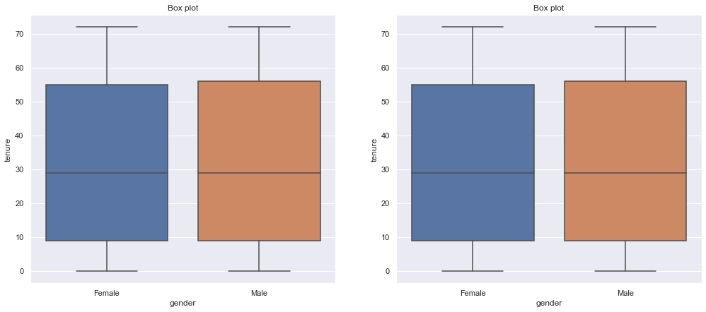

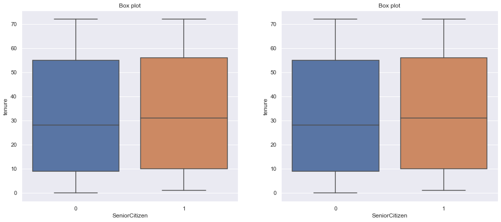

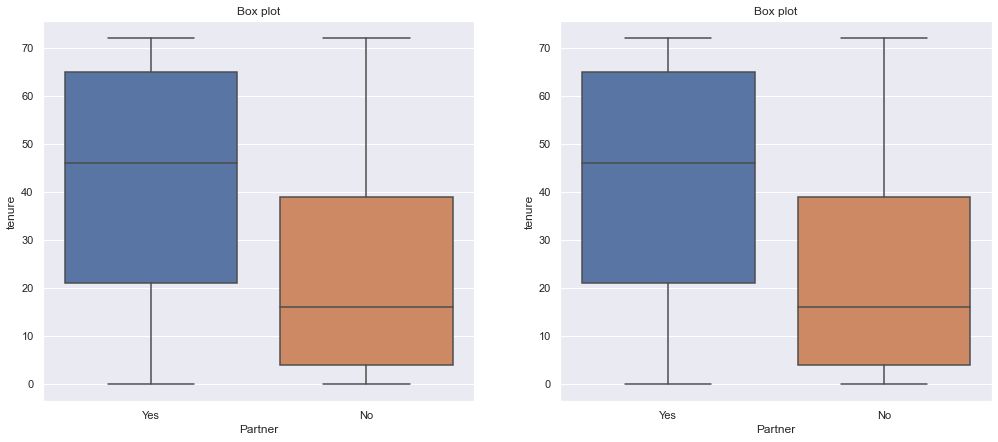

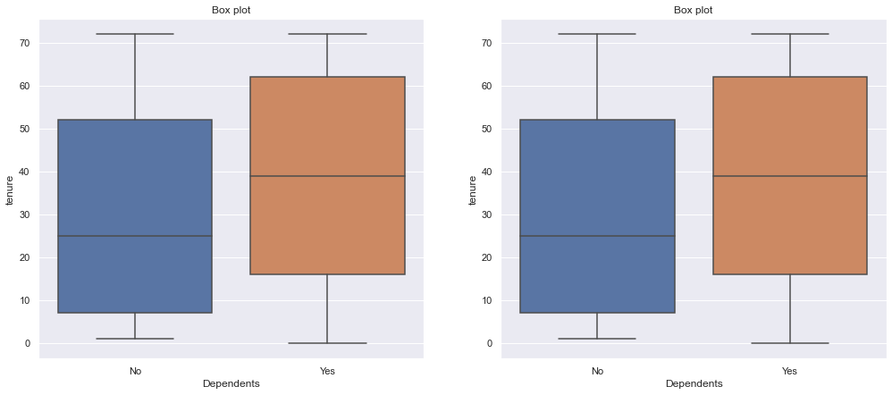

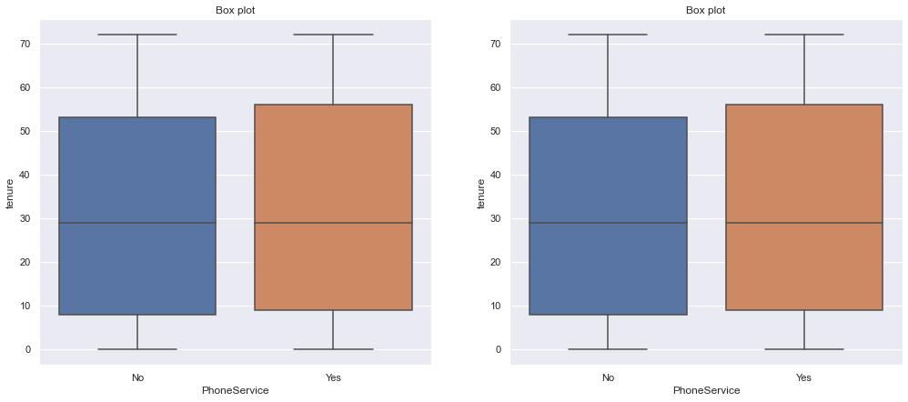

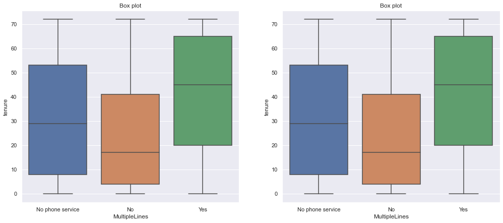

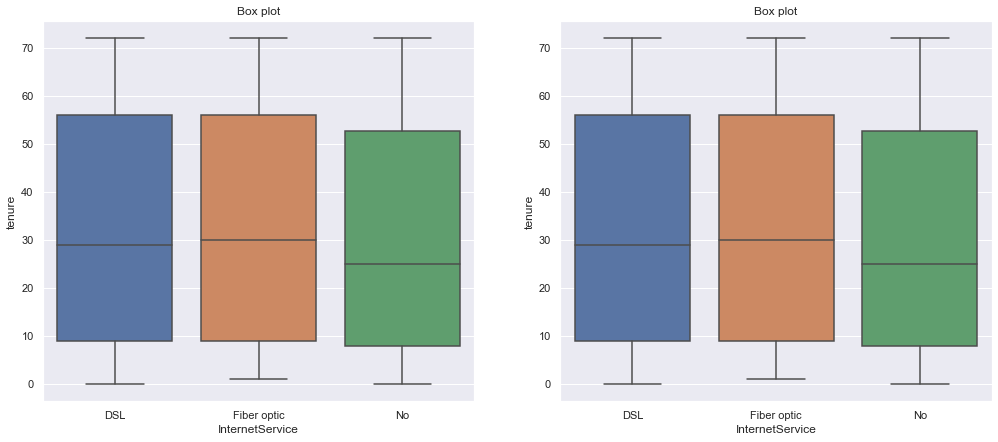

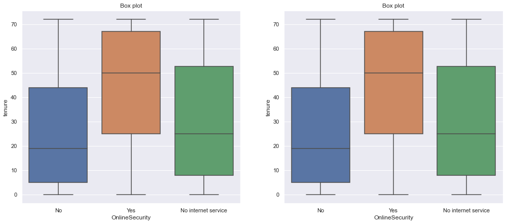

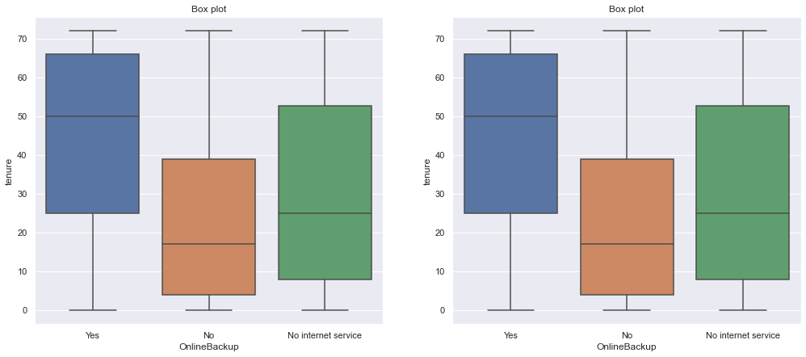

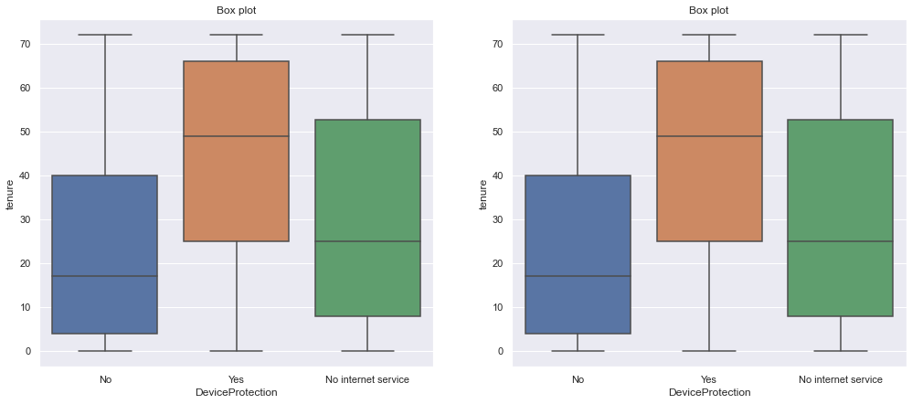

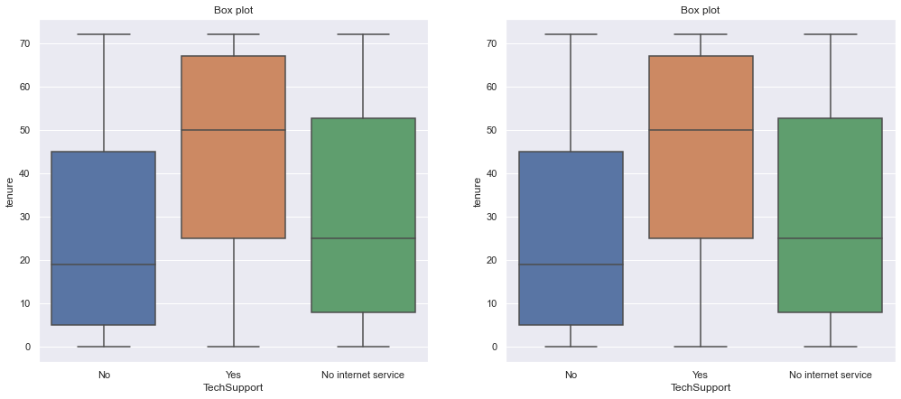

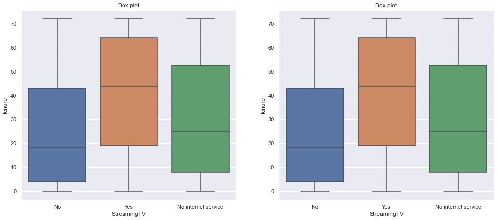

[5 more figures not shown]

```python
for col in df_tel.select_dtypes(include=['object']).columns:
#     sns.countplot(df_tel.loc[:, df_tel.select_dtypes(include=['object']).columns])
    f, axes = plt.subplots(1, 2, figsize=(17,7))
    sns.boxplot(x = col, y="tenure", data=df_tel, ax=axes[0])
    sns.boxplot(x = col, y="tenure", data=df_tel, ax=axes[1])
    axes[0].set_title('Box plot')
    axes[1].set_title('Box plot')
    plt.show()
```

###### Univariate Analysis for outliers in continous variables

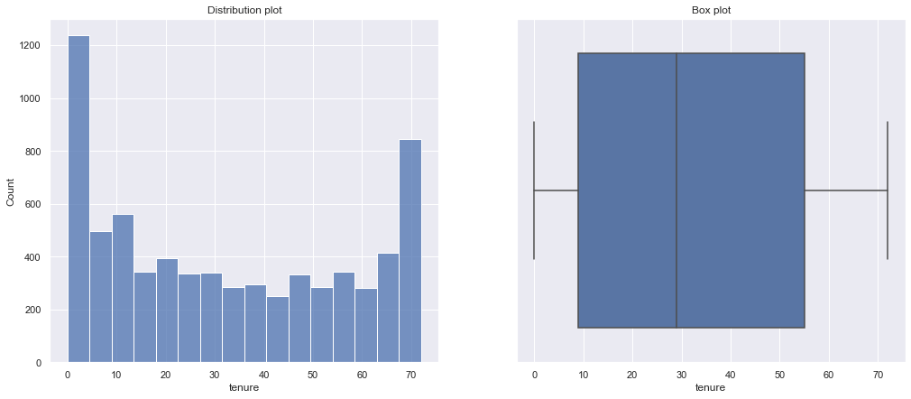

```
 Total Number of outliers in tenure: 0
```

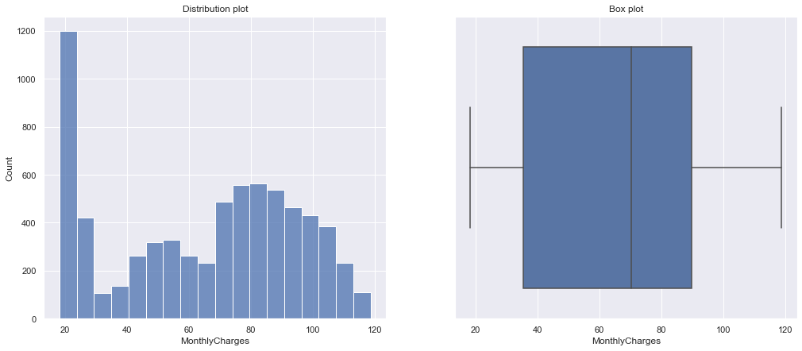

```
 Total Number of outliers in MonthlyCharges: 0
```

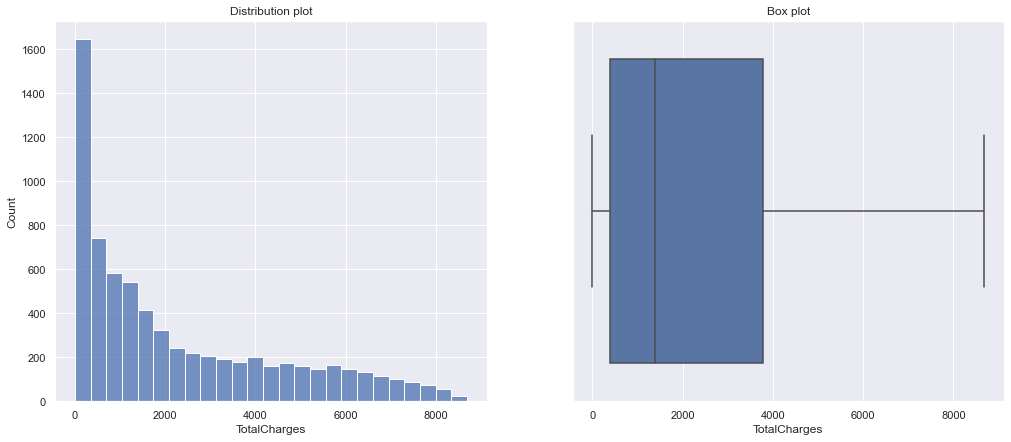

```
 Total Number of outliers in TotalCharges: 0
```

```python
# Looping through all continous features
for col in list(df_tel.select_dtypes(include=['int64','float64']).columns):
    # Display Univariate analysis, Histogram and Boxplot
    f, axes = plt.subplots(1, 2, figsize=(17,7))
    sns.boxplot(x = col, data=df_tel,  orient='h' , ax=axes[1])
    sns.histplot(df_tel[col],  ax=axes[0])
    axes[0].set_title('Distribution plot')
    axes[1].set_title('Box plot')
    plt.show()

    # checking count of outliers.
    q25, q75 = np.percentile(df_tel[col], 25), np.percentile(df_tel[col], 75)
    IQR = q75-q25
    threshold=IQR*1.5
    lower, upper = q25 - threshold, q75 + threshold
    outliers = [i for i in df_tel[col] if i < lower or i > upper]
    print('{} Total Number of outliers in {}: {}'.format('\033[1m', col, len(outliers)))
```

###### Multivariate Analysis of continous variables

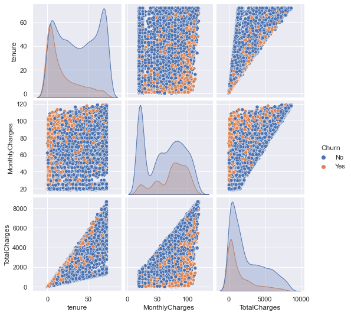

```python
# Multivariate Analysis
sns.pairplot(data=df_tel[["tenure", "MonthlyCharges", "TotalCharges", "Churn"]],
             hue="Churn")
```

#### 4. Data pre-processing: [ Score: 5 point ]

###### • Segregate predictors vs target attributes

```python
# Segregating target variable
target = df_tel.loc[:, "Churn"]

# Segregating predictors
predictors = df_tel.iloc[:, :-1]
```

###### • Check for target balancing and fix it if found imbalanced.

```python
df_tel.info()
```

```
<class 'pandas.core.frame.DataFrame'>
RangeIndex: 7043 entries, 0 to 7042
Data columns (total 20 columns):
 #   Column            Non-Null Count  Dtype
---  ------            --------------  -----
 0   gender            7043 non-null   object
 1   SeniorCitizen     7043 non-null   object
 2   Partner           7043 non-null   object
 3   Dependents        7043 non-null   object
 4   tenure            7043 non-null   int64
 5   PhoneService      7043 non-null   object
 6   MultipleLines     7043 non-null   object
 7   InternetService   7043 non-null   object
 8   OnlineSecurity    7043 non-null   object
 9   OnlineBackup      7043 non-null   object
 10  DeviceProtection  7043 non-null   object
 11  TechSupport       7043 non-null   object
 12  StreamingTV       7043 non-null   object
 13  StreamingMovies   7043 non-null   object
 14  Contract          7043 non-null   object
 15  PaperlessBilling  7043 non-null   object
 16  PaymentMethod     7043 non-null   object
 17  MonthlyCharges    7043 non-null   float64
 18  TotalCharges      7043 non-null   float64
 19  Churn             7043 non-null   object
dtypes: float64(2), int64(1), object(17)
memory usage: 1.1+ MB
```

```python
print('Proportion of target variable that is Churn("Yes") is ', sum(df_tel["Churn"] == "Yes")/df_tel.shape[0])
```

```
Proportion of target variable that is Churn("Yes") is  0.2653698707936959
```

###### From Inference 2 we see that only 113 records out of 1526 records are churnable, which is 7%. While in the Total Set 27% is Churned records. Based on this information, to reduce dimensionality and also to achieve a better class balance we will drop these specific 1526 records.

```python
# Dropping records with Internet Service == "No"
df_tel.drop(df_tel[df_tel["InternetService"] == "No"].index, inplace=True)
df_tel.reset_index(drop=True, inplace=True)
```

###### At this point we will separate the train and test set before oversampling to achieve target class balance since we want the test data to be as untouched as possible.

```python
# Get the dummy variables and drop the first one
one_hot_X = pd.get_dummies(df_tel.drop('Churn', axis=1), drop_first=True)
one_hot_X.shape
```

```
(5517, 23)
```

```python
# Displaying Dummy variable dataset
one_hot_X
```

|  | tenure | MonthlyCharges | TotalCharges | gender_Male | SeniorCitizen_1 | Partner_Yes | Dependents_Yes | PhoneService_Yes | MultipleLines_No phone service | MultipleLines_Yes | ... | DeviceProtection_Yes | TechSupport_Yes | StreamingTV_Yes | StreamingMovies_Yes | Contract_One year | Contract_Two year | PaperlessBilling_Yes | PaymentMethod_Credit card (automatic) | PaymentMethod_Electronic check | PaymentMethod_Mailed check |
| --- | --- | --- | --- | --- | --- | --- | --- | --- | --- | --- | --- | --- | --- | --- | --- | --- | --- | --- | --- | --- | --- |
| 0 | 1 | 29.85 | 29.85 | 0 | 0 | 1 | 0 | 0 | 1 | 0 | ... | 0 | 0 | 0 | 0 | 0 | 0 | 1 | 0 | 1 | 0 |
| 1 | 34 | 56.95 | 1889.50 | 1 | 0 | 0 | 0 | 1 | 0 | 0 | ... | 1 | 0 | 0 | 0 | 1 | 0 | 0 | 0 | 0 | 1 |
| 2 | 2 | 53.85 | 108.15 | 1 | 0 | 0 | 0 | 1 | 0 | 0 | ... | 0 | 0 | 0 | 0 | 0 | 0 | 1 | 0 | 0 | 1 |
| 3 | 45 | 42.30 | 1840.75 | 1 | 0 | 0 | 0 | 0 | 1 | 0 | ... | 1 | 1 | 0 | 0 | 1 | 0 | 0 | 0 | 0 | 0 |
| 4 | 2 | 70.70 | 151.65 | 0 | 0 | 0 | 0 | 1 | 0 | 0 | ... | 0 | 0 | 0 | 0 | 0 | 0 | 1 | 0 | 1 | 0 |
| ... | ... | ... | ... | ... | ... | ... | ... | ... | ... | ... | ... | ... | ... | ... | ... | ... | ... | ... | ... | ... | ... |
| 5512 | 24 | 84.80 | 1990.50 | 1 | 0 | 1 | 1 | 1 | 0 | 1 | ... | 1 | 1 | 1 | 1 | 1 | 0 | 1 | 0 | 0 | 1 |
| 5513 | 72 | 103.20 | 7362.90 | 0 | 0 | 1 | 1 | 1 | 0 | 1 | ... | 1 | 0 | 1 | 1 | 1 | 0 | 1 | 1 | 0 | 0 |
| 5514 | 11 | 29.60 | 346.45 | 0 | 0 | 1 | 1 | 0 | 1 | 0 | ... | 0 | 0 | 0 | 0 | 0 | 0 | 1 | 0 | 1 | 0 |
| 5515 | 4 | 74.40 | 306.60 | 1 | 1 | 1 | 0 | 1 | 0 | 1 | ... | 0 | 0 | 0 | 0 | 0 | 0 | 1 | 0 | 0 | 1 |
| 5516 | 66 | 105.65 | 6844.50 | 1 | 0 | 0 | 0 | 1 | 0 | 0 | ... | 1 | 1 | 1 | 1 | 0 | 1 | 1 | 0 | 0 | 0 |

5517 rows × 23 columns

```python
# # Separate input features and target
y = df_tel["Churn"].replace({"Yes": 1, "No": 0})
# X = encoded_df.drop('Churn', axis=1)

# setting up testing and training sets
X_train, X_test, y_train, y_test = train_test_split(one_hot_X, y, test_size=0.25, random_state=42)

# Using SMOTE to create new datas around actual data of minor class till a ratio of 1:1 between the 2 classes
sm = SMOTE(random_state=42, sampling_strategy=1.0)
X_train, y_train = sm.fit_resample(X_train, y_train)
```

```python
# Quick glance at the class distribution post Synthetic Minority Overclass Technique
np.unique(y_train, return_counts=True)
```

```
(array([0, 1], dtype=int64), array([2826, 2826], dtype=int64))
```

###### • Perform train-test split.

```python
# Displaying the train data information for predictors
X_train.info()
print()

# Quick glance at the class distribution post Synthetic Minority Overclass Technique
print("Churn : No,Yes")
print(np.unique(y_train, return_counts=True))
print()

# Displaying the test data information for predictors
X_test.info()
print()

# Displaying the test data distribution for target
print("Churn : No,Yes")
print(np.unique(y_test, return_counts=True))
```

```
<class 'pandas.core.frame.DataFrame'>
RangeIndex: 5652 entries, 0 to 5651
Data columns (total 23 columns):
 #   Column                                 Non-Null Count  Dtype
---  ------                                 --------------  -----
 0   tenure                                 5652 non-null   int64
 1   MonthlyCharges                         5652 non-null   float64
 2   TotalCharges                           5652 non-null   float64
 3   gender_Male                            5652 non-null   uint8
 4   SeniorCitizen_1                        5652 non-null   uint8
 5   Partner_Yes                            5652 non-null   uint8
 6   Dependents_Yes                         5652 non-null   uint8
 7   PhoneService_Yes                       5652 non-null   uint8
 8   MultipleLines_No phone service         5652 non-null   uint8
 9   MultipleLines_Yes                      5652 non-null   uint8
 10  InternetService_Fiber optic            5652 non-null   uint8
 11  OnlineSecurity_Yes                     5652 non-null   uint8
 12  OnlineBackup_Yes                       5652 non-null   uint8
 13  DeviceProtection_Yes                   5652 non-null   uint8
 14  TechSupport_Yes                        5652 non-null   uint8
 15  StreamingTV_Yes                        5652 non-null   uint8
 16  StreamingMovies_Yes                    5652 non-null   uint8
 17  Contract_One year                      5652 non-null   uint8
 18  Contract_Two year                      5652 non-null   uint8
 19  PaperlessBilling_Yes                   5652 non-null   uint8
 20  PaymentMethod_Credit card (automatic)  5652 non-null   uint8
 21  PaymentMethod_Electronic check         5652 non-null   uint8
 22  PaymentMethod_Mailed check             5652 non-null   uint8
dtypes: float64(2), int64(1), uint8(20)
memory usage: 243.0 KB

Churn : No,Yes
(array([0, 1], dtype=int64), array([2826, 2826], dtype=int64))

<class 'pandas.core.frame.DataFrame'>
Int64Index: 1380 entries, 1615 to 196
Data columns (total 23 columns):
 #   Column                                 Non-Null Count  Dtype
---  ------                                 --------------  -----
 0   tenure                                 1380 non-null   int64
```

[output cut: 12 more lines]

```
 13  DeviceProtection_Yes                   1380 non-null   uint8
 14  TechSupport_Yes                        1380 non-null   uint8
 15  StreamingTV_Yes                        1380 non-null   uint8
 16  StreamingMovies_Yes                    1380 non-null   uint8
 17  Contract_One year                      1380 non-null   uint8
 18  Contract_Two year                      1380 non-null   uint8
 19  PaperlessBilling_Yes                   1380 non-null   uint8
 20  PaymentMethod_Credit card (automatic)  1380 non-null   uint8
 21  PaymentMethod_Electronic check         1380 non-null   uint8
 22  PaymentMethod_Mailed check             1380 non-null   uint8
dtypes: float64(2), int64(1), uint8(20)
memory usage: 70.1 KB

Churn : No,Yes
(array([0, 1], dtype=int64), array([935, 445], dtype=int64))
```

###### • Check if the train and test data have similar statistical characteristics when compared with original data.

```python
# Calculate and display the Original data set at 25% versus the actual data set size
print("Original data set test ratio at 25% is ", 0.25*df_tel.shape[0])
print("Test set size is ", len(X_test))

# Calculate and display the Original data Churn(Yes) proportion versus the Test data set Churn(Yes) proportion
print("Proportion of Churn(Yes) in Original data set ", sum(df_tel["Churn"]==1)/df_tel.shape[0])
print("Proportion of Churn(Yes) in test set ", sum(y_test)/len(y_test))
```

```
Original data set test ratio at 25% is  1379.25
Test set size is  1380
Proportion of Churn(Yes) in Original data set  0.0
Proportion of Churn(Yes) in test set  0.322463768115942
```

#### 5. Model training, testing and tuning: [ Score: 15 point ]

###### • Train and test all ensemble models taught in the learning module.

###### Instead of looking at the generic versions of all models we will Tune the models and do a grid search to try to focus on the best hyperparameters

###### • Apply all the possible tuning techniques to train the best model for the given data.

###### We will combine this question and the next because using all the possible hyper parameter combinations and tuning best model overlapped.

###### It is very important to note that we will use precision as our primary metric to determine best fit. This is because we would rather predict Churn and get it right than any other possibilities, because of the cost of getting Churn wrong.

###### • Suggestion: Use all possible hyper parameter combinations to extract the best accuracies.

###### Tuning max depth

```python
###### GridSearchCV to find optimal n_estimators
#from sklearn.model_selection import KFold

# specify number of folds for k-fold CV
n_folds = 5

# parameters to build the model on
parameters = {'max_depth': range(2, 250, 30)}

# instantiate the model
rf = RandomForestClassifier()

# Set the metrics for evaluation
scoring = ['precision', 'accuracy','f1_macro']

# fit tree on training data
rf = GridSearchCV(rf, parameters,
                    cv=n_folds,
                   scoring=scoring,
                 refit='accuracy')
rf.fit(X_train, y_train)
```

```
GridSearchCV(cv=5, estimator=RandomForestClassifier(),
             param_grid={'max_depth': range(2, 250, 30)}, refit='accuracy',
             scoring=['precision', 'accuracy', 'f1_macro'])
```

```python
###### scores of GridSearch CV
scores = rf.cv_results_
pd.DataFrame(scores).iloc[: , 12::8]
```

|  | std_test_precision | std_test_accuracy | std_test_f1_macro |
| --- | --- | --- | --- |
| 0 | 0.023767 | 0.048481 | 0.047600 |
| 1 | 0.017204 | 0.071114 | 0.072836 |
| 2 | 0.018303 | 0.072122 | 0.073812 |
| 3 | 0.019118 | 0.075757 | 0.077703 |
| 4 | 0.018557 | 0.074683 | 0.076650 |
| 5 | 0.021927 | 0.074920 | 0.076615 |
| 6 | 0.015662 | 0.072477 | 0.074147 |
| 7 | 0.014909 | 0.072192 | 0.074133 |
| 8 | 0.020650 | 0.076577 | 0.078600 |

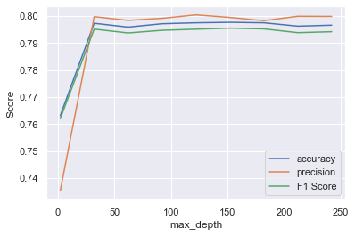

```python
# plotting scores with max_depth
plt.figure()
plt.plot(scores["param_max_depth"],
         scores["mean_test_accuracy"],
         label="accuracy")
plt.plot(scores["param_max_depth"],
         scores["mean_test_precision"],
         label="precision")
plt.plot(scores["param_max_depth"],
         scores["mean_test_f1_macro"],
         label="F1 Score")
plt.xlabel("max_depth")
plt.ylabel("Score")
plt.legend()
plt.show()
```

###### Inference 3: Increasing max_depth is not particularly causing overfitting since the drop in precision is not particularly high as we go higher, but there is a peak between 100 and 150

###### Tuning n-estimators

```python
# specify number of folds for k-fold CV
n_folds = 5

# parameters to build the model on
parameters = {'n_estimators': range(100, 1500, 400)}

# instantiate the model
rf = RandomForestClassifier()

# Set the metrics for evaluation
scoring = ['precision', 'accuracy','f1_macro']

# fit tree on training data
rf = GridSearchCV(rf, parameters,
                    cv=n_folds,
                   scoring=scoring,
                 refit='accuracy')
rf.fit(X_train, y_train)
```

```
GridSearchCV(cv=5, estimator=RandomForestClassifier(),
             param_grid={'n_estimators': range(100, 1500, 400)},
             refit='accuracy', scoring=['precision', 'accuracy', 'f1_macro'])
```

```python
###### scores of GridSearch CV
scores = rf.cv_results_
pd.DataFrame(scores)
```

|  | mean_fit_time | std_fit_time | mean_score_time | std_score_time | param_n_estimators | params | split0_test_precision | split1_test_precision | split2_test_precision | split3_test_precision | ... | std_test_accuracy | rank_test_accuracy | split0_test_f1_macro | split1_test_f1_macro | split2_test_f1_macro | split3_test_f1_macro | split4_test_f1_macro | mean_test_f1_macro | std_test_f1_macro | rank_test_f1_macro |
| --- | --- | --- | --- | --- | --- | --- | --- | --- | --- | --- | --- | --- | --- | --- | --- | --- | --- | --- | --- | --- | --- |
| 0 | 0.445594 | 0.035075 | 0.030033 | 0.000754 | 100 | {'n_estimators': 100} | 0.770302 | 0.770335 | 0.819095 | 0.830275 | ... | 0.078662 | 1 | 0.701378 | 0.695043 | 0.837037 | 0.881566 | 0.861637 | 0.795333 | 0.080569 | 1 |
| 1 | 1.996092 | 0.055852 | 0.130248 | 0.011354 | 500 | {'n_estimators': 500} | 0.783217 | 0.771635 | 0.808013 | 0.826748 | ... | 0.075629 | 2 | 0.710222 | 0.694899 | 0.826392 | 0.879716 | 0.863467 | 0.794939 | 0.077534 | 2 |
| 2 | 3.651588 | 0.046328 | 0.248093 | 0.004710 | 900 | {'n_estimators': 900} | 0.774713 | 0.771226 | 0.808264 | 0.823708 | ... | 0.074585 | 3 | 0.707004 | 0.699058 | 0.829875 | 0.876152 | 0.860857 | 0.794589 | 0.076271 | 3 |
| 3 | 5.300689 | 0.144325 | 0.358170 | 0.008908 | 1300 | {'n_estimators': 1300} | 0.777778 | 0.771429 | 0.815126 | 0.819820 | ... | 0.074534 | 4 | 0.707718 | 0.696984 | 0.831740 | 0.876001 | 0.858067 | 0.794102 | 0.076301 | 4 |

4 rows × 30 columns

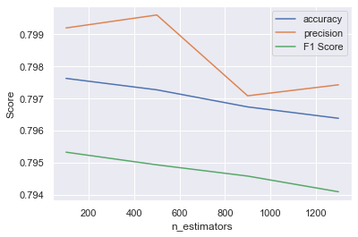

```python
# plotting scores with n_estimators
plt.figure()
plt.plot(scores["param_n_estimators"],
         scores["mean_test_accuracy"],
         label="accuracy")
plt.plot(scores["param_n_estimators"],
         scores["mean_test_precision"],
         label="precision")
plt.plot(scores["param_n_estimators"],
         scores["mean_test_f1_macro"],
         label="F1 Score")
plt.xlabel("n_estimators")
plt.ylabel("Score")
plt.legend()
plt.show()
```

###### Tuning max_features

```python
# specify number of folds for k-fold CV
n_folds = 5

# parameters to build the model on
parameters = {'max_features': [2, 8, 14, 20, None]}

# instantiate the model
rf = RandomForestClassifier()

# Set the metrics for evaluation
scoring = ['precision', 'accuracy','f1_macro']

# fit tree on training data
rf = GridSearchCV(rf, parameters,
                    cv=n_folds,
                   scoring=scoring,
                 refit='accuracy')
rf.fit(X_train, y_train)
```

```
GridSearchCV(cv=5, estimator=RandomForestClassifier(),
             param_grid={'max_features': [2, 8, 14, 20, None]},
             refit='accuracy', scoring=['precision', 'accuracy', 'f1_macro'])
```

```python
###### scores of GridSearch CV
scores = rf.cv_results_
pd.DataFrame(scores)
```

|  | mean_fit_time | std_fit_time | mean_score_time | std_score_time | param_max_features | params | split0_test_precision | split1_test_precision | split2_test_precision | split3_test_precision | ... | std_test_accuracy | rank_test_accuracy | split0_test_f1_macro | split1_test_f1_macro | split2_test_f1_macro | split3_test_f1_macro | split4_test_f1_macro | mean_test_f1_macro | std_test_f1_macro | rank_test_f1_macro |
| --- | --- | --- | --- | --- | --- | --- | --- | --- | --- | --- | --- | --- | --- | --- | --- | --- | --- | --- | --- | --- | --- |
| 0 | 0.319564 | 0.026089 | 0.030680 | 0.001536 | 2 | {'max_features': 2} | 0.770833 | 0.767386 | 0.821248 | 0.818043 | ... | 0.076872 | 2 | 0.702338 | 0.692272 | 0.837068 | 0.867319 | 0.865338 | 0.792867 | 0.078821 | 1 |
| 1 | 0.527272 | 0.026981 | 0.027856 | 0.003928 | 8 | {'max_features': 8} | 0.781250 | 0.780952 | 0.802676 | 0.828267 | ... | 0.074165 | 1 | 0.701270 | 0.704177 | 0.820201 | 0.881498 | 0.857150 | 0.792859 | 0.076146 | 2 |
| 2 | 0.791359 | 0.025047 | 0.026095 | 0.004729 | 14 | {'max_features': 14} | 0.771363 | 0.782297 | 0.803306 | 0.815592 | ... | 0.072406 | 3 | 0.703297 | 0.704039 | 0.824559 | 0.871520 | 0.858888 | 0.792461 | 0.074110 | 3 |
| 3 | 1.093397 | 0.077586 | 0.024783 | 0.004077 | 20 | {'max_features': 20} | 0.778846 | 0.770686 | 0.792079 | 0.827957 | ... | 0.073934 | 5 | 0.699470 | 0.698091 | 0.813028 | 0.877165 | 0.853529 | 0.788257 | 0.075884 | 5 |
| 4 | 1.154404 | 0.019993 | 0.023033 | 0.003778 | None | {'max_features': None} | 0.782082 | 0.767773 | 0.786535 | 0.829231 | ... | 0.076456 | 4 | 0.700155 | 0.695326 | 0.808559 | 0.878071 | 0.865252 | 0.789473 | 0.078483 | 4 |

5 rows × 30 columns

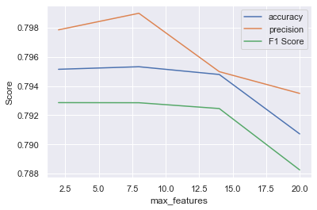

```python
# plotting scores with max_features
plt.figure()
plt.plot(scores["param_max_features"],
         scores["mean_test_accuracy"],
         label="accuracy")
plt.plot(scores["param_max_features"],
         scores["mean_test_precision"],
         label="precision")
plt.plot(scores["param_max_features"],
         scores["mean_test_f1_macro"],
         label="F1 Score")
plt.xlabel("max_features")
plt.ylabel("Score")
plt.legend()
plt.show()
```

###### Inference 5: Max features learns more at the start but then starts overfiting post 8 features

###### Tuning min_sample_leaf

```python
# specify number of folds for k-fold CV
n_folds = 5

# parameters to build the model on
parameters = {'min_samples_leaf': range(100, 400, 50)}

# instantiate the model
rf = RandomForestClassifier()

# Set the metrics for evaluation
scoring = ['precision', 'accuracy','f1_macro']

# fit tree on training data
rf = GridSearchCV(rf, parameters,
                    cv=n_folds,
                   scoring=scoring,
                 refit='accuracy')
rf.fit(X_train, y_train)
```

```
GridSearchCV(cv=5, estimator=RandomForestClassifier(),
             param_grid={'min_samples_leaf': range(100, 400, 50)},
             refit='accuracy', scoring=['precision', 'accuracy', 'f1_macro'])
```

```python
###### scores of GridSearch CV
scores = rf.cv_results_
pd.DataFrame(scores)
```

|  | mean_fit_time | std_fit_time | mean_score_time | std_score_time | param_min_samples_leaf | params | split0_test_precision | split1_test_precision | split2_test_precision | split3_test_precision | ... | std_test_accuracy | rank_test_accuracy | split0_test_f1_macro | split1_test_f1_macro | split2_test_f1_macro | split3_test_f1_macro | split4_test_f1_macro | mean_test_f1_macro | std_test_f1_macro | rank_test_f1_macro |
| --- | --- | --- | --- | --- | --- | --- | --- | --- | --- | --- | --- | --- | --- | --- | --- | --- | --- | --- | --- | --- | --- |
| 0 | 0.234441 | 0.008564 | 0.019901 | 0.000805 | 100 | {'min_samples_leaf': 100} | 0.738956 | 0.730315 | 0.774092 | 0.799679 | ... | 0.051797 | 2 | 0.708970 | 0.706567 | 0.806378 | 0.830511 | 0.797214 | 0.769928 | 0.051911 | 2 |
| 1 | 0.214189 | 0.006466 | 0.017770 | 0.002955 | 150 | {'min_samples_leaf': 150} | 0.736000 | 0.719165 | 0.764890 | 0.807018 | ... | 0.054963 | 1 | 0.707256 | 0.704335 | 0.798273 | 0.840227 | 0.803815 | 0.770781 | 0.054992 | 1 |
| 2 | 0.205490 | 0.003542 | 0.018969 | 0.000999 | 200 | {'min_samples_leaf': 200} | 0.721470 | 0.719231 | 0.776699 | 0.803890 | ... | 0.052958 | 3 | 0.701496 | 0.701540 | 0.802220 | 0.831502 | 0.778959 | 0.763143 | 0.053001 | 3 |
| 3 | 0.196597 | 0.003920 | 0.015767 | 0.003910 | 250 | {'min_samples_leaf': 250} | 0.720472 | 0.723735 | 0.770867 | 0.792208 | ... | 0.049027 | 4 | 0.696843 | 0.703174 | 0.792577 | 0.818214 | 0.780858 | 0.758333 | 0.049172 | 4 |
| 4 | 0.210232 | 0.012075 | 0.019790 | 0.005085 | 300 | {'min_samples_leaf': 300} | 0.717647 | 0.714015 | 0.769726 | 0.790620 | ... | 0.049018 | 5 | 0.695123 | 0.699927 | 0.795959 | 0.806925 | 0.788160 | 0.757219 | 0.049127 | 5 |
| 5 | 0.173753 | 0.011905 | 0.015469 | 0.003490 | 350 | {'min_samples_leaf': 350} | 0.718391 | 0.719770 | 0.758170 | 0.785358 | ... | 0.044176 | 6 | 0.700717 | 0.702447 | 0.779264 | 0.803340 | 0.788862 | 0.754926 | 0.044228 | 6 |

6 rows × 30 columns

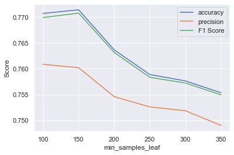

```python
# plotting scores with min_samples_leaf
plt.figure()
plt.plot(scores["param_min_samples_leaf"],
         scores["mean_test_accuracy"],
         label="accuracy")
plt.plot(scores["param_min_samples_leaf"],
         scores["mean_test_precision"],
         label="precision")
plt.plot(scores["param_min_samples_leaf"],
         scores["mean_test_f1_macro"],
         label="F1 Score")
plt.xlabel("min_samples_leaf")
plt.ylabel("Score")
plt.legend()
plt.show()
```

###### Tuning min_samples_split

```python
# specify number of folds for k-fold CV
n_folds = 5

# parameters to build the model on
parameters = {'min_samples_split': range(200, 2000, 200)}

# instantiate the model
rf = RandomForestClassifier()

# Set the metrics for evaluation
scoring = ['precision', 'accuracy','f1_macro']

# fit tree on training data
rf = GridSearchCV(rf, parameters,
                    cv=n_folds,
                   scoring=scoring,
                 refit='accuracy')
rf.fit(X_train, y_train)
```

```
GridSearchCV(cv=5, estimator=RandomForestClassifier(),
             param_grid={'min_samples_split': range(200, 2000, 200)},
             refit='accuracy', scoring=['precision', 'accuracy', 'f1_macro'])
```

```python
###### scores of GridSearch CV
scores = rf.cv_results_
pd.DataFrame(scores)
```

|  | mean_fit_time | std_fit_time | mean_score_time | std_score_time | param_min_samples_split | params | split0_test_precision | split1_test_precision | split2_test_precision | split3_test_precision | ... | std_test_accuracy | rank_test_accuracy | split0_test_f1_macro | split1_test_f1_macro | split2_test_f1_macro | split3_test_f1_macro | split4_test_f1_macro | mean_test_f1_macro | std_test_f1_macro | rank_test_f1_macro |
| --- | --- | --- | --- | --- | --- | --- | --- | --- | --- | --- | --- | --- | --- | --- | --- | --- | --- | --- | --- | --- | --- |
| 0 | 0.260406 | 0.011194 | 0.020613 | 0.000670 | 200 | {'min_samples_split': 200} | 0.748344 | 0.742424 | 0.790083 | 0.815457 | ... | 0.066759 | 1 | 0.695511 | 0.695926 | 0.810382 | 0.853436 | 0.829966 | 0.777044 | 0.067787 | 1 |
| 1 | 0.218712 | 0.008086 | 0.020441 | 0.000029 | 400 | {'min_samples_split': 400} | 0.745536 | 0.734151 | 0.787479 | 0.812401 | ... | 0.063632 | 2 | 0.690767 | 0.701534 | 0.808585 | 0.847298 | 0.819380 | 0.773513 | 0.064507 | 2 |
| 2 | 0.208704 | 0.004841 | 0.015111 | 0.003479 | 600 | {'min_samples_split': 600} | 0.748315 | 0.731557 | 0.784185 | 0.807571 | ... | 0.063308 | 3 | 0.691487 | 0.698833 | 0.805040 | 0.844553 | 0.821205 | 0.772224 | 0.064206 | 3 |
| 3 | 0.191868 | 0.001430 | 0.016137 | 0.004226 | 800 | {'min_samples_split': 800} | 0.733634 | 0.747323 | 0.785595 | 0.806349 | ... | 0.062498 | 5 | 0.678845 | 0.702406 | 0.801611 | 0.841067 | 0.808195 | 0.766425 | 0.063754 | 5 |
| 4 | 0.187401 | 0.004659 | 0.012921 | 0.003737 | 1000 | {'min_samples_split': 1000} | 0.732739 | 0.731250 | 0.777778 | 0.806604 | ... | 0.065145 | 4 | 0.680994 | 0.694965 | 0.796230 | 0.844519 | 0.816046 | 0.766551 | 0.066112 | 4 |
| 5 | 0.170505 | 0.011491 | 0.016705 | 0.004493 | 1200 | {'min_samples_split': 1200} | 0.737288 | 0.731161 | 0.778702 | 0.794915 | ... | 0.050029 | 7 | 0.695554 | 0.699829 | 0.796253 | 0.807871 | 0.798528 | 0.759607 | 0.050721 | 7 |
| 6 | 0.153100 | 0.000103 | 0.016330 | 0.004264 | 1400 | {'min_samples_split': 1400} | 0.727651 | 0.712355 | 0.764992 | 0.789557 | ... | 0.052397 | 9 | 0.691490 | 0.694410 | 0.788934 | 0.823273 | 0.774067 | 0.754435 | 0.052686 | 9 |
| 7 | 0.163531 | 0.000101 | 0.014314 | 0.005002 | 1600 | {'min_samples_split': 1600} | 0.730924 | 0.714008 | 0.751667 | 0.782609 | ... | 0.054641 | 6 | 0.701872 | 0.694314 | 0.767033 | 0.821250 | 0.818513 | 0.760596 | 0.054620 | 6 |
| 8 | 0.160263 | 0.003538 | 0.013550 | 0.002389 | 1800 | {'min_samples_split': 1800} | 0.717557 | 0.713483 | 0.762987 | 0.788732 | ... | 0.044493 | 8 | 0.700756 | 0.701795 | 0.786290 | 0.790264 | 0.797861 | 0.755393 | 0.044344 | 8 |

9 rows × 30 columns

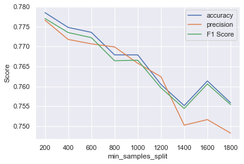

```python
# plotting scores with min_samples_split
plt.figure()
plt.plot(scores["param_min_samples_split"],
         scores["mean_test_accuracy"],
         label="accuracy")
plt.plot(scores["param_min_samples_split"],
         scores["mean_test_precision"],
         label="precision")
plt.plot(scores["param_min_samples_split"],
         scores["mean_test_f1_macro"],
         label="F1 Score")
plt.xlabel("min_samples_split")
plt.ylabel("Score")
plt.legend()
plt.show()
```

###### Tuning Random Forest Hyperparameters

```python
# Create the parameter grid based on the results of random search
param_grid = {
    'max_depth': range(107, 138, 15),
    'min_samples_leaf': range(50, 150, 50),
    'min_samples_split': range(100, 300, 100),
    'n_estimators': [300, 500, 700],
    'max_features': [8]
}
# Create a based model
rf = RandomForestClassifier()
# Instantiate the grid search model
grid_search = GridSearchCV(estimator = rf, param_grid = param_grid,
                          cv = 3, n_jobs = -1, verbose = 1)
```

```python
# Fit the grid search to the data
start = time.time()
grid_search.fit(X_train, y_train)
end = time.time()
print("Time", end-start)
```

```
Fitting 3 folds for each of 36 candidates, totalling 108 fits
Time 44.01030492782593
```

```python
# printing the optimal accuracy score and hyperparameters
print('We can get accuracy of',grid_search.best_score_,'using',grid_search.best_params_)
best_params_rf = grid_search.best_estimator_
```

```
We can get accuracy of 0.7691082802547772 using {'max_depth': 137, 'max_features': 8, 'min_samples_leaf': 50, 'min_samples_split': 200, 'n_estimators': 700}
```

###### Tuning ADA Hyperparameters

```python
# parameter grid
param_grid = {"learning_rate": [0.1, 0.15, 0.2],
              'base_estimator__max_depth': range(77, 107, 15),
              'base_estimator__min_samples_leaf': range(50, 150, 50),
              'base_estimator__min_samples_split': range(50, 300, 100),
              'n_estimators': [100, 200, 300],
              'base_estimator__max_features': [8]
             }
```

```python
# base estimator
tree = DecisionTreeClassifier()

# from sklearn import metrics

# adaboost with the tree as base estimator
# learning rate is arbitrarily set to 0.6, we'll discuss learning_rate below
ABC = AdaBoostClassifier(
    base_estimator=tree,
    algorithm="SAMME", random_state=42)
```

```python
# run grid search
folds = 5
grid_search_ABC = GridSearchCV(ABC,
                               cv = folds,
                               param_grid=param_grid,
                               scoring = scoring,
                               return_train_score=True,
                               verbose = 1,
                              refit='accuracy')
```

```python
# fit
grid_search_ABC.fit(X_train, y_train)
```

```
Fitting 5 folds for each of 108 candidates, totalling 540 fits
```

```
GridSearchCV(cv=5,
             estimator=AdaBoostClassifier(algorithm='SAMME',
                                          base_estimator=DecisionTreeClassifier(),
                                          random_state=42),
             param_grid={'base_estimator__max_depth': range(77, 107, 15),
                         'base_estimator__max_features': [8],
                         'base_estimator__min_samples_leaf': range(50, 150, 50),
                         'base_estimator__min_samples_split': range(50, 300, 100),
                         'learning_rate': [0.1, 0.15, 0.2],
                         'n_estimators': [100, 200, 300]},
             refit='accuracy', return_train_score=True,
             scoring=['precision', 'accuracy', 'f1_macro'], verbose=1)
```

```python
# cv results
cv_results = pd.DataFrame(grid_search_ABC.cv_results_)
cv_results
```

|  | mean_fit_time | std_fit_time | mean_score_time | std_score_time | param_base_estimator__max_depth | param_base_estimator__max_features | param_base_estimator__min_samples_leaf | param_base_estimator__min_samples_split | param_learning_rate | param_n_estimators | ... | mean_test_f1_macro | std_test_f1_macro | rank_test_f1_macro | split0_train_f1_macro | split1_train_f1_macro | split2_train_f1_macro | split3_train_f1_macro | split4_train_f1_macro | mean_train_f1_macro | std_train_f1_macro |
| --- | --- | --- | --- | --- | --- | --- | --- | --- | --- | --- | --- | --- | --- | --- | --- | --- | --- | --- | --- | --- | --- |
| 0 | 0.655181 | 0.020556 | 0.028132 | 0.002923 | 77 | 8 | 50 | 50 | 0.1 | 100 | ... | 0.794178 | 0.081269 | 55 | 0.909090 | 0.912177 | 0.889872 | 0.877044 | 0.875938 | 0.892824 | 0.015375 |
| 1 | 1.312825 | 0.029496 | 0.050960 | 0.005741 | 77 | 8 | 50 | 50 | 0.1 | 200 | ... | 0.793474 | 0.086053 | 63 | 0.951116 | 0.950891 | 0.934985 | 0.928792 | 0.927243 | 0.938605 | 0.010450 |
| 2 | 1.939346 | 0.045696 | 0.072797 | 0.004413 | 77 | 8 | 50 | 50 | 0.1 | 300 | ... | 0.792779 | 0.088594 | 73 | 0.981862 | 0.982083 | 0.968376 | 0.964838 | 0.960637 | 0.971559 | 0.008849 |
| 3 | 0.660338 | 0.062468 | 0.028383 | 0.004087 | 77 | 8 | 50 | 50 | 0.15 | 100 | ... | 0.791557 | 0.086409 | 89 | 0.929661 | 0.932753 | 0.913974 | 0.900044 | 0.906015 | 0.916489 | 0.012841 |
| 4 | 1.313599 | 0.036770 | 0.049425 | 0.000872 | 77 | 8 | 50 | 50 | 0.15 | 200 | ... | 0.791289 | 0.088283 | 97 | 0.979650 | 0.980978 | 0.969482 | 0.964175 | 0.962626 | 0.971382 | 0.007651 |
| ... | ... | ... | ... | ... | ... | ... | ... | ... | ... | ... | ... | ... | ... | ... | ... | ... | ... | ... | ... | ... | ... |
| 103 | 1.115375 | 0.044407 | 0.041092 | 0.000798 | 92 | 8 | 100 | 250 | 0.15 | 200 | ... | 0.793347 | 0.088333 | 65 | 0.909528 | 0.910624 | 0.883016 | 0.875272 | 0.878814 | 0.891451 | 0.015408 |
| 104 | 1.596264 | 0.062839 | 0.062748 | 0.003356 | 92 | 8 | 100 | 250 | 0.15 | 300 | ... | 0.794644 | 0.090831 | 47 | 0.935190 | 0.934300 | 0.912207 | 0.903803 | 0.898275 | 0.916755 | 0.015347 |
| 105 | 0.556402 | 0.032093 | 0.022889 | 0.003942 | 92 | 8 | 100 | 250 | 0.2 | 100 | ... | 0.791374 | 0.084953 | 95 | 0.892057 | 0.891613 | 0.863997 | 0.850720 | 0.856029 | 0.870883 | 0.017622 |
| 106 | 1.077470 | 0.019944 | 0.039665 | 0.003541 | 92 | 8 | 100 | 250 | 0.2 | 200 | ... | 0.791248 | 0.089319 | 99 | 0.927004 | 0.925447 | 0.905128 | 0.888764 | 0.894737 | 0.908216 | 0.015617 |
| 107 | 1.658154 | 0.077638 | 0.062218 | 0.003217 | 92 | 8 | 100 | 250 | 0.2 | 300 | ... | 0.794354 | 0.089031 | 49 | 0.951780 | 0.953326 | 0.933879 | 0.920389 | 0.922822 | 0.936439 | 0.013929 |

108 rows × 56 columns

```python
# Displaying the best parameters
grid_search_ABC.best_estimator_
```

```
AdaBoostClassifier(algorithm='SAMME',
                   base_estimator=DecisionTreeClassifier(max_depth=77,
                                                         max_features=8,
                                                         min_samples_leaf=50,
                                                         min_samples_split=250),
                   learning_rate=0.15, n_estimators=200, random_state=42)
```

```python
# Displaying the scores of the ideal hyperparameters
cv_results.loc[(cv_results["param_base_estimator__max_depth"] == 77) & (cv_results["param_learning_rate"]==0.15) &
               (cv_results["param_base_estimator__min_samples_leaf"]==50) &
               (cv_results["param_base_estimator__min_samples_split"]==250) &
               (cv_results["param_n_estimators"]==200),
               ["mean_test_f1_macro", "std_test_f1_macro", "mean_test_accuracy",
                 "std_test_accuracy", "mean_test_precision", "std_test_precision",
                "mean_train_f1_macro", "std_train_f1_macro", "mean_train_accuracy",
                 "std_train_accuracy", "mean_train_precision", "std_train_precision",
                "mean_score_time"]]
```

|  | mean_test_f1_macro | std_test_f1_macro | mean_test_accuracy | std_test_accuracy | mean_test_precision | std_test_precision | mean_train_f1_macro | std_train_f1_macro | mean_train_accuracy | std_train_accuracy | mean_train_precision | std_train_precision | mean_score_time |
| --- | --- | --- | --- | --- | --- | --- | --- | --- | --- | --- | --- | --- | --- |
| 22 | 0.799676 | 0.084462 | 0.802759 | 0.081666 | 0.80864 | 0.015804 | 0.916223 | 0.014182 | 0.916226 | 0.014184 | 0.92049 | 0.016768 | 0.044646 |

```python
# Displaying the parameters of the Best Precision
cv_results.loc[cv_results["mean_test_precision"].argmax(), 'params']
```

```
{'base_estimator__max_depth': 77,
 'base_estimator__max_features': 8,
 'base_estimator__min_samples_leaf': 50,
 'base_estimator__min_samples_split': 250,
 'learning_rate': 0.15,
 'n_estimators': 200}
```

###### Gradient Boosting Classifier

```python
# parameter grid
param_grid = {"learning_rate": [0.1, 0.15, 0.2],
              "subsample": [0.3, 0.6, 0.9],
              "max_depth": range(92, 123, 15),
              'min_samples_leaf': range(50, 100, 50),
              'min_samples_split': range(100, 200, 100),
              'n_estimators': [200, 250, 300],
              'max_features': [8]
             }
```

```python
# adaboost with the tree as base estimator
GBC = GradientBoostingClassifier(random_state=42)
```

```python
# run grid search
folds = 5
grid_search_GBC = GridSearchCV(GBC,
                               cv = folds,
                               param_grid=param_grid,
                               scoring = scoring,
                               return_train_score=True,
                               verbose = 1,
                              refit='accuracy')

grid_search_GBC.fit(X_train, y_train)
```

```
Fitting 5 folds for each of 81 candidates, totalling 405 fits
```

```
GridSearchCV(cv=5, estimator=GradientBoostingClassifier(random_state=42),
             param_grid={'learning_rate': [0.1, 0.15, 0.2],
                         'max_depth': range(92, 123, 15), 'max_features': [8],
                         'min_samples_leaf': range(50, 100, 50),
                         'min_samples_split': range(100, 200, 100),
                         'n_estimators': [200, 250, 300],
                         'subsample': [0.3, 0.6, 0.9]},
             refit='accuracy', return_train_score=True,
             scoring=['precision', 'accuracy', 'f1_macro'], verbose=1)
```

```python
cv_results = pd.DataFrame(grid_search_GBC.cv_results_)
cv_results
```

|  | mean_fit_time | std_fit_time | mean_score_time | std_score_time | param_learning_rate | param_max_depth | param_max_features | param_min_samples_leaf | param_min_samples_split | param_n_estimators | ... | mean_test_f1_macro | std_test_f1_macro | rank_test_f1_macro | split0_train_f1_macro | split1_train_f1_macro | split2_train_f1_macro | split3_train_f1_macro | split4_train_f1_macro | mean_train_f1_macro | std_train_f1_macro |
| --- | --- | --- | --- | --- | --- | --- | --- | --- | --- | --- | --- | --- | --- | --- | --- | --- | --- | --- | --- | --- | --- |
| 0 | 0.546165 | 0.015484 | 0.011815 | 0.003185 | 0.1 | 92 | 8 | 50 | 100 | 200 | ... | 0.793681 | 0.088530 | 67 | 0.893164 | 0.892050 | 0.863112 | 0.845848 | 0.848297 | 0.868494 | 0.020558 |
| 1 | 0.913630 | 0.017745 | 0.013118 | 0.003764 | 0.1 | 92 | 8 | 50 | 100 | 200 | ... | 0.794440 | 0.088010 | 52 | 0.943596 | 0.941158 | 0.927023 | 0.911099 | 0.911764 | 0.926928 | 0.013862 |
| 2 | 1.387934 | 0.064656 | 0.015394 | 0.004839 | 0.1 | 92 | 8 | 50 | 100 | 200 | ... | 0.799393 | 0.087466 | 16 | 0.977438 | 0.980314 | 0.968155 | 0.964174 | 0.960637 | 0.970143 | 0.007571 |
| 3 | 0.653218 | 0.004543 | 0.013737 | 0.004501 | 0.1 | 92 | 8 | 50 | 100 | 250 | ... | 0.794115 | 0.088749 | 58 | 0.901346 | 0.903778 | 0.872621 | 0.855805 | 0.858027 | 0.878315 | 0.020637 |
| 4 | 1.147246 | 0.009320 | 0.018318 | 0.004104 | 0.1 | 92 | 8 | 50 | 100 | 250 | ... | 0.797169 | 0.090025 | 31 | 0.956868 | 0.960405 | 0.940070 | 0.931003 | 0.929897 | 0.943649 | 0.012785 |
| ... | ... | ... | ... | ... | ... | ... | ... | ... | ... | ... | ... | ... | ... | ... | ... | ... | ... | ... | ... | ... | ... |
| 76 | 1.349016 | 0.055296 | 0.021236 | 0.006021 | 0.2 | 122 | 8 | 50 | 100 | 250 | ... | 0.793969 | 0.088808 | 64 | 0.986950 | 0.990710 | 0.980981 | 0.977001 | 0.976116 | 0.982351 | 0.005664 |
| 77 | 1.966512 | 0.087646 | 0.021741 | 0.001167 | 0.2 | 122 | 8 | 50 | 100 | 250 | ... | 0.798884 | 0.087981 | 19 | 0.997567 | 0.998230 | 0.996683 | 0.995798 | 0.996683 | 0.996992 | 0.000834 |
| 78 | 0.821521 | 0.013692 | 0.016574 | 0.000485 | 0.2 | 122 | 8 | 50 | 100 | 300 | ... | 0.793035 | 0.087963 | 76 | 0.930767 | 0.936296 | 0.913091 | 0.900264 | 0.898496 | 0.915783 | 0.015442 |
| 79 | 1.778365 | 0.163281 | 0.025598 | 0.005087 | 0.2 | 122 | 8 | 50 | 100 | 300 | ... | 0.793326 | 0.087916 | 73 | 0.992258 | 0.994691 | 0.989164 | 0.984520 | 0.984962 | 0.989119 | 0.003984 |
| 80 | 2.471587 | 0.100146 | 0.026835 | 0.003675 | 0.2 | 122 | 8 | 50 | 100 | 300 | ... | 0.795813 | 0.086893 | 40 | 0.997567 | 0.998673 | 0.997346 | 0.996462 | 0.997567 | 0.997523 | 0.000705 |

81 rows × 57 columns

```python
# Displaying the most ideal hyperparameters
grid_search_GBC.best_estimator_
```

```
GradientBoostingClassifier(learning_rate=0.15, max_depth=92, max_features=8,
                           min_samples_leaf=50, min_samples_split=100,
                           n_estimators=250, random_state=42, subsample=0.6)
```

```python
# Displaying the best test scores
cv_results.loc[(cv_results["param_max_depth"] == 92) & (cv_results["param_learning_rate"]==0.15) &
               (cv_results["param_min_samples_leaf"]==50) &
               (cv_results["param_min_samples_split"]==100) &
               (cv_results["param_n_estimators"]==250) &
               (cv_results["param_subsample"]==0.6),
               ["mean_test_f1_macro", "std_test_f1_macro", "mean_test_accuracy",
                 "std_test_accuracy", "mean_test_precision", "std_test_precision",
                "mean_train_f1_macro", "std_train_f1_macro", "mean_train_accuracy",
                 "std_train_accuracy", "mean_train_precision", "std_train_precision",
                "mean_score_time"]]
```

|  | mean_test_f1_macro | std_test_f1_macro | mean_test_accuracy | std_test_accuracy | mean_test_precision | std_test_precision | mean_train_f1_macro | std_train_f1_macro | mean_train_accuracy | std_train_accuracy | mean_train_precision | std_train_precision | mean_score_time |
| --- | --- | --- | --- | --- | --- | --- | --- | --- | --- | --- | --- | --- | --- |
| 31 | 0.801816 | 0.089103 | 0.804707 | 0.086513 | 0.808013 | 0.023882 | 0.969436 | 0.008828 | 0.969436 | 0.008827 | 0.966289 | 0.010041 | 0.017853 |

```python
# Displaying the parameters of the Best Precision
cv_results.loc[cv_results["mean_test_precision"].argmax(), 'params']
```

```
{'learning_rate': 0.1,
 'max_depth': 92,
 'max_features': 8,
 'min_samples_leaf': 50,
 'min_samples_split': 100,
 'n_estimators': 250,
 'subsample': 0.9}
```

###### Bagging Classifier

```python
# parameter grid
param_grid = {"max_samples": [50, 150, 250, 350, 450, 550],
              "base_estimator__max_depth": range(107, 138, 15),
              'base_estimator__min_samples_leaf': range(50, 100, 50),
              'base_estimator__min_samples_split': range(100, 200, 100),
              'n_estimators': [300, 500, 700],
              'max_features': [8]
             }
```

```python
bag = BaggingClassifier(DecisionTreeClassifier(), bootstrap=True, n_jobs=-1, random_state=42)

# run grid search
folds = 5
grid_search_bag = GridSearchCV(bag,
                               cv = folds,
                               param_grid=param_grid,
                               scoring = scoring,
                               return_train_score=True,
                               verbose = 1,
                              refit='accuracy')

grid_search_bag.fit(X_train, y_train)
```

```
Fitting 5 folds for each of 54 candidates, totalling 270 fits
```

[output not shown]

[output cut: 58 more lines]

```
GridSearchCV(cv=5,
             estimator=BaggingClassifier(base_estimator=DecisionTreeClassifier(),
                                         n_jobs=-1, random_state=42),
             param_grid={'base_estimator__max_depth': range(107, 138, 15),
                         'base_estimator__min_samples_leaf': range(50, 100, 50),
                         'base_estimator__min_samples_split': range(100, 200, 100),
                         'max_features': [8],
                         'max_samples': [50, 150, 250, 350, 450, 550],
                         'n_estimators': [300, 500, 700]},
             refit='accuracy', return_train_score=True,
             scoring=['precision', 'accuracy', 'f1_macro'], verbose=1)
```

```python
cv_results = pd.DataFrame(grid_search_bag.cv_results_)
cv_results
```

|  | mean_fit_time | std_fit_time | mean_score_time | std_score_time | param_base_estimator__max_depth | param_base_estimator__min_samples_leaf | param_base_estimator__min_samples_split | param_max_features | param_max_samples | param_n_estimators | ... | mean_test_f1_macro | std_test_f1_macro | rank_test_f1_macro | split0_train_f1_macro | split1_train_f1_macro | split2_train_f1_macro | split3_train_f1_macro | split4_train_f1_macro | mean_train_f1_macro | std_train_f1_macro |
| --- | --- | --- | --- | --- | --- | --- | --- | --- | --- | --- | --- | --- | --- | --- | --- | --- | --- | --- | --- | --- | --- |
| 0 | 0.574584 | 0.829615 | 0.077514 | 0.011052 | 107 | 50 | 100 | 8 | 50 | 300 | ... | 0.333412 | 0.000096 | 46 | 0.333284 | 0.333284 | 0.333333 | 0.333333 | 0.333333 | 0.333314 | 0.000024 |
| 1 | 0.272335 | 0.019451 | 0.121445 | 0.008244 | 107 | 50 | 100 | 8 | 50 | 500 | ... | 0.333412 | 0.000096 | 46 | 0.333284 | 0.333284 | 0.333333 | 0.333333 | 0.333333 | 0.333314 | 0.000024 |
| 2 | 0.413570 | 0.053196 | 0.163628 | 0.021470 | 107 | 50 | 100 | 8 | 50 | 700 | ... | 0.333412 | 0.000096 | 46 | 0.333284 | 0.333284 | 0.333333 | 0.333333 | 0.333333 | 0.333314 | 0.000024 |
| 3 | 0.187205 | 0.019847 | 0.087287 | 0.011582 | 107 | 50 | 100 | 8 | 150 | 300 | ... | 0.704151 | 0.018614 | 37 | 0.707565 | 0.705351 | 0.701407 | 0.702563 | 0.701448 | 0.703667 | 0.002420 |
| 4 | 0.297703 | 0.038009 | 0.129068 | 0.017351 | 107 | 50 | 100 | 8 | 150 | 500 | ... | 0.702559 | 0.017579 | 40 | 0.707115 | 0.706475 | 0.699884 | 0.699467 | 0.700109 | 0.702610 | 0.003429 |
| 5 | 0.380796 | 0.013974 | 0.156247 | 0.009334 | 107 | 50 | 100 | 8 | 150 | 700 | ... | 0.701839 | 0.017258 | 43 | 0.706020 | 0.708248 | 0.699018 | 0.700123 | 0.699887 | 0.702659 | 0.003739 |
| 6 | 0.185877 | 0.027597 | 0.101862 | 0.045840 | 107 | 50 | 100 | 8 | 250 | 300 | ... | 0.739173 | 0.036255 | 31 | 0.768635 | 0.763074 | 0.741260 | 0.734626 | 0.739938 | 0.749507 | 0.013645 |
| 7 | 0.303927 | 0.042229 | 0.148826 | 0.040553 | 107 | 50 | 100 | 8 | 250 | 500 | ... | 0.740433 | 0.034651 | 28 | 0.768191 | 0.765281 | 0.741928 | 0.735291 | 0.740822 | 0.750303 | 0.013636 |
| 8 | 0.383368 | 0.010052 | 0.166249 | 0.030729 | 107 | 50 | 100 | 8 | 250 | 700 | ... | 0.736191 | 0.034361 | 34 | 0.765970 | 0.761541 | 0.739717 | 0.735278 | 0.740152 | 0.748532 | 0.012625 |
| 9 | 0.176613 | 0.017878 | 0.080345 | 0.012772 | 107 | 50 | 100 | 8 | 350 | 300 | ... | 0.750423 | 0.038474 | 19 | 0.786316 | 0.777672 | 0.749662 | 0.745871 | 0.752492 | 0.762403 | 0.016364 |
| 10 | 0.296118 | 0.018753 | 0.135902 | 0.013720 | 107 | 50 | 100 | 8 | 350 | 500 | ... | 0.748979 | 0.039612 | 22 | 0.784987 | 0.776557 | 0.750749 | 0.746744 | 0.751384 | 0.762085 | 0.015571 |
| 11 | 0.413239 | 0.019386 | 0.173301 | 0.020857 | 107 | 50 | 100 | 8 | 350 | 700 | ... | 0.746684 | 0.037701 | 25 | 0.782551 | 0.776115 | 0.749860 | 0.746485 | 0.750235 | 0.761049 | 0.015123 |
| 12 | 0.179426 | 0.007800 | 0.080046 | 0.006555 | 107 | 50 | 100 | 8 | 450 | 300 | ... | 0.756935 | 0.039093 | 10 | 0.789318 | 0.787490 | 0.759311 | 0.754874 | 0.755303 | 0.769259 | 0.015719 |
| 13 | 0.293723 | 0.014954 | 0.124650 | 0.006583 | 107 | 50 | 100 | 8 | 450 | 500 | ... | 0.756246 | 0.038786 | 13 | 0.791312 | 0.784864 | 0.759071 | 0.754185 | 0.757063 | 0.769299 | 0.015554 |
| 14 | 0.399559 | 0.010825 | 0.159299 | 0.006217 | 107 | 50 | 100 | 8 | 450 | 700 | ... | 0.755340 | 0.039411 | 16 | 0.791071 | 0.783531 | 0.761436 | 0.753487 | 0.757022 | 0.769309 | 0.015094 |
| 15 | 0.213038 | 0.058711 | 0.086815 | 0.010667 | 107 | 50 | 100 | 8 | 550 | 300 | ... | 0.761296 | 0.046462 | 1 | 0.794401 | 0.790514 | 0.769029 | 0.759281 | 0.766128 | 0.775871 | 0.013963 |
| 16 | 0.342203 | 0.052107 | 0.133342 | 0.009037 | 107 | 50 | 100 | 8 | 550 | 500 | ... | 0.759515 | 0.044855 | 4 | 0.793950 | 0.790562 | 0.768788 | 0.760589 | 0.763691 | 0.775516 | 0.013958 |
| 17 | 0.397130 | 0.005937 | 0.156132 | 0.008210 | 107 | 50 | 100 | 8 | 550 | 700 | ... | 0.758646 | 0.044248 | 7 | 0.794826 | 0.790365 | 0.770315 | 0.761458 | 0.761666 | 0.775726 | 0.014210 |
| 18 | 0.169774 | 0.002903 | 0.078458 | 0.007352 | 122 | 50 | 100 | 8 | 50 | 300 | ... | 0.333412 | 0.000096 | 46 | 0.333284 | 0.333284 | 0.333333 | 0.333333 | 0.333333 | 0.333314 | 0.000024 |
| 19 | 0.260796 | 0.004857 | 0.116815 | 0.012302 | 122 | 50 | 100 | 8 | 50 | 500 | ... | 0.333412 | 0.000096 | 46 | 0.333284 | 0.333284 | 0.333333 | 0.333333 | 0.333333 | 0.333314 | 0.000024 |
| 20 | 0.358604 | 0.003898 | 0.169462 | 0.011094 | 122 | 50 | 100 | 8 | 50 | 700 | ... | 0.333412 | 0.000096 | 46 | 0.333284 | 0.333284 | 0.333333 | 0.333333 | 0.333333 | 0.333314 | 0.000024 |
| 21 | 0.169549 | 0.011571 | 0.078176 | 0.009234 | 122 | 50 | 100 | 8 | 150 | 300 | ... | 0.704151 | 0.018614 | 37 | 0.707565 | 0.705351 | 0.701407 | 0.702563 | 0.701448 | 0.703667 | 0.002420 |
| 22 | 0.284914 | 0.009056 | 0.114461 | 0.007355 | 122 | 50 | 100 | 8 | 150 | 500 | ... | 0.702559 | 0.017579 | 40 | 0.707115 | 0.706475 | 0.699884 | 0.699467 | 0.700109 | 0.702610 | 0.003429 |
| 23 | 0.369941 | 0.006896 | 0.162020 | 0.007099 | 122 | 50 | 100 | 8 | 150 | 700 | ... | 0.701839 | 0.017258 | 43 | 0.706020 | 0.708248 | 0.699018 | 0.700123 | 0.699887 | 0.702659 | 0.003739 |
| 24 | 0.168710 | 0.008894 | 0.081595 | 0.010387 | 122 | 50 | 100 | 8 | 250 | 300 | ... | 0.739173 | 0.036255 | 31 | 0.768635 | 0.763074 | 0.741260 | 0.734626 | 0.739938 | 0.749507 | 0.013645 |
| 25 | 0.272612 | 0.007988 | 0.117942 | 0.006725 | 122 | 50 | 100 | 8 | 250 | 500 | ... | 0.740433 | 0.034651 | 28 | 0.768191 | 0.765281 | 0.741928 | 0.735291 | 0.740822 | 0.750303 | 0.013636 |
| 26 | 0.375403 | 0.003043 | 0.153734 | 0.007303 | 122 | 50 | 100 | 8 | 250 | 700 | ... | 0.736191 | 0.034361 | 34 | 0.765970 | 0.761541 | 0.739717 | 0.735278 | 0.740152 | 0.748532 | 0.012625 |
| 27 | 0.185429 | 0.019088 | 0.090112 | 0.009016 | 122 | 50 | 100 | 8 | 350 | 300 | ... | 0.750423 | 0.038474 | 19 | 0.786316 | 0.777672 | 0.749662 | 0.745871 | 0.752492 | 0.762403 | 0.016364 |
| 28 | 0.278257 | 0.010588 | 0.120491 | 0.005498 | 122 | 50 | 100 | 8 | 350 | 500 | ... | 0.748979 | 0.039612 | 22 | 0.784987 | 0.776557 | 0.750749 | 0.746744 | 0.751384 | 0.762085 | 0.015571 |
| 29 | 0.381963 | 0.009644 | 0.153967 | 0.014504 | 122 | 50 | 100 | 8 | 350 | 700 | ... | 0.746684 | 0.037701 | 25 | 0.782551 | 0.776115 | 0.749860 | 0.746485 | 0.750235 | 0.761049 | 0.015123 |
| 30 | 0.179872 | 0.007806 | 0.082707 | 0.005533 | 122 | 50 | 100 | 8 | 450 | 300 | ... | 0.756935 | 0.039093 | 10 | 0.789318 | 0.787490 | 0.759311 | 0.754874 | 0.755303 | 0.769259 | 0.015719 |
| 31 | 0.282862 | 0.007340 | 0.135327 | 0.016444 | 122 | 50 | 100 | 8 | 450 | 500 | ... | 0.756246 | 0.038786 | 13 | 0.791312 | 0.784864 | 0.759071 | 0.754185 | 0.757063 | 0.769299 | 0.015554 |
| 32 | 0.384724 | 0.005238 | 0.169960 | 0.009174 | 122 | 50 | 100 | 8 | 450 | 700 | ... | 0.755340 | 0.039411 | 16 | 0.791071 | 0.783531 | 0.761436 | 0.753487 | 0.757022 | 0.769309 | 0.015094 |
| 33 | 0.187222 | 0.012631 | 0.083132 | 0.009014 | 122 | 50 | 100 | 8 | 550 | 300 | ... | 0.761296 | 0.046462 | 1 | 0.794401 | 0.790514 | 0.769029 | 0.759281 | 0.766128 | 0.775871 | 0.013963 |
| 34 | 0.285563 | 0.006176 | 0.125378 | 0.009112 | 122 | 50 | 100 | 8 | 550 | 500 | ... | 0.759515 | 0.044855 | 4 | 0.793950 | 0.790562 | 0.768788 | 0.760589 | 0.763691 | 0.775516 | 0.013958 |
| 35 | 0.399130 | 0.006074 | 0.158119 | 0.007492 | 122 | 50 | 100 | 8 | 550 | 700 | ... | 0.758646 | 0.044248 | 7 | 0.794826 | 0.790365 | 0.770315 | 0.761458 | 0.761666 | 0.775726 | 0.014210 |
| 36 | 0.163716 | 0.006750 | 0.072683 | 0.005546 | 137 | 50 | 100 | 8 | 50 | 300 | ... | 0.333412 | 0.000096 | 46 | 0.333284 | 0.333284 | 0.333333 | 0.333333 | 0.333333 | 0.333314 | 0.000024 |
| 37 | 0.264170 | 0.014378 | 0.124062 | 0.011643 | 137 | 50 | 100 | 8 | 50 | 500 | ... | 0.333412 | 0.000096 | 46 | 0.333284 | 0.333284 | 0.333333 | 0.333333 | 0.333333 | 0.333314 | 0.000024 |
| 38 | 0.361147 | 0.015774 | 0.151940 | 0.008898 | 137 | 50 | 100 | 8 | 50 | 700 | ... | 0.333412 | 0.000096 | 46 | 0.333284 | 0.333284 | 0.333333 | 0.333333 | 0.333333 | 0.333314 | 0.000024 |
| 39 | 0.169051 | 0.005434 | 0.070248 | 0.005357 | 137 | 50 | 100 | 8 | 150 | 300 | ... | 0.704151 | 0.018614 | 37 | 0.707565 | 0.705351 | 0.701407 | 0.702563 | 0.701448 | 0.703667 | 0.002420 |
| 40 | 0.267247 | 0.006668 | 0.107345 | 0.009725 | 137 | 50 | 100 | 8 | 150 | 500 | ... | 0.702559 | 0.017579 | 40 | 0.707115 | 0.706475 | 0.699884 | 0.699467 | 0.700109 | 0.702610 | 0.003429 |
| 41 | 0.376666 | 0.021071 | 0.170583 | 0.016504 | 137 | 50 | 100 | 8 | 150 | 700 | ... | 0.701839 | 0.017258 | 43 | 0.706020 | 0.708248 | 0.699018 | 0.700123 | 0.699887 | 0.702659 | 0.003739 |
| 42 | 0.165202 | 0.004545 | 0.078471 | 0.009942 | 137 | 50 | 100 | 8 | 250 | 300 | ... | 0.739173 | 0.036255 | 31 | 0.768635 | 0.763074 | 0.741260 | 0.734626 | 0.739938 | 0.749507 | 0.013645 |
| 43 | 0.272920 | 0.012615 | 0.128834 | 0.003234 | 137 | 50 | 100 | 8 | 250 | 500 | ... | 0.740433 | 0.034651 | 28 | 0.768191 | 0.765281 | 0.741928 | 0.735291 | 0.740822 | 0.750303 | 0.013636 |
| 44 | 0.389017 | 0.010686 | 0.161610 | 0.007654 | 137 | 50 | 100 | 8 | 250 | 700 | ... | 0.736191 | 0.034361 | 34 | 0.765970 | 0.761541 | 0.739717 | 0.735278 | 0.740152 | 0.748532 | 0.012625 |
| 45 | 0.168831 | 0.008031 | 0.079124 | 0.006008 | 137 | 50 | 100 | 8 | 350 | 300 | ... | 0.750423 | 0.038474 | 19 | 0.786316 | 0.777672 | 0.749662 | 0.745871 | 0.752492 | 0.762403 | 0.016364 |
| 46 | 0.275291 | 0.006134 | 0.133668 | 0.015802 | 137 | 50 | 100 | 8 | 350 | 500 | ... | 0.748979 | 0.039612 | 22 | 0.784987 | 0.776557 | 0.750749 | 0.746744 | 0.751384 | 0.762085 | 0.015571 |
| 47 | 0.389991 | 0.008198 | 0.162951 | 0.006775 | 137 | 50 | 100 | 8 | 350 | 700 | ... | 0.746684 | 0.037701 | 25 | 0.782551 | 0.776115 | 0.749860 | 0.746485 | 0.750235 | 0.761049 | 0.015123 |
| 48 | 0.176589 | 0.009821 | 0.078812 | 0.003975 | 137 | 50 | 100 | 8 | 450 | 300 | ... | 0.756935 | 0.039093 | 10 | 0.789318 | 0.787490 | 0.759311 | 0.754874 | 0.755303 | 0.769259 | 0.015719 |
| 49 | 0.288747 | 0.019749 | 0.118458 | 0.013513 | 137 | 50 | 100 | 8 | 450 | 500 | ... | 0.756246 | 0.038786 | 13 | 0.791312 | 0.784864 | 0.759071 | 0.754185 | 0.757063 | 0.769299 | 0.015554 |
| 50 | 0.399841 | 0.011134 | 0.178806 | 0.011312 | 137 | 50 | 100 | 8 | 450 | 700 | ... | 0.755340 | 0.039411 | 16 | 0.791071 | 0.783531 | 0.761436 | 0.753487 | 0.757022 | 0.769309 | 0.015094 |
| 51 | 0.178722 | 0.009339 | 0.084262 | 0.008321 | 137 | 50 | 100 | 8 | 550 | 300 | ... | 0.761296 | 0.046462 | 1 | 0.794401 | 0.790514 | 0.769029 | 0.759281 | 0.766128 | 0.775871 | 0.013963 |
| 52 | 0.291185 | 0.005073 | 0.129023 | 0.004168 | 137 | 50 | 100 | 8 | 550 | 500 | ... | 0.759515 | 0.044855 | 4 | 0.793950 | 0.790562 | 0.768788 | 0.760589 | 0.763691 | 0.775516 | 0.013958 |
| 53 | 0.410459 | 0.017450 | 0.177198 | 0.024824 | 137 | 50 | 100 | 8 | 550 | 700 | ... | 0.758646 | 0.044248 | 7 | 0.794826 | 0.790365 | 0.770315 | 0.761458 | 0.761666 | 0.775726 | 0.014210 |

54 rows × 56 columns

```python
grid_search_bag.best_estimator_
```

```
BaggingClassifier(base_estimator=DecisionTreeClassifier(max_depth=107,
                                                        min_samples_leaf=50,
                                                        min_samples_split=100),
                  max_features=8, max_samples=550, n_estimators=300, n_jobs=-1,
                  random_state=42)
```

```python
cv_results.loc[(cv_results["param_base_estimator__max_depth"] == 107) & (cv_results["param_max_samples"]==550) &
               (cv_results["param_base_estimator__min_samples_leaf"]==50) &
               (cv_results["param_base_estimator__min_samples_split"]==100) &
               (cv_results["param_n_estimators"]==300),
               ["mean_test_f1_macro", "std_test_f1_macro", "mean_test_accuracy",
                 "std_test_accuracy", "mean_test_precision", "std_test_precision",
                "mean_train_f1_macro", "std_train_f1_macro", "mean_train_accuracy",
                 "std_train_accuracy", "mean_train_precision", "std_train_precision",
                "mean_score_time"]]
```

|  | mean_test_f1_macro | std_test_f1_macro | mean_test_accuracy | std_test_accuracy | mean_test_precision | std_test_precision | mean_train_f1_macro | std_train_f1_macro | mean_train_accuracy | std_train_accuracy | mean_train_precision | std_train_precision | mean_score_time |
| --- | --- | --- | --- | --- | --- | --- | --- | --- | --- | --- | --- | --- | --- |
| 15 | 0.761296 | 0.046462 | 0.761697 | 0.046495 | 0.752302 | 0.027909 | 0.775871 | 0.013963 | 0.77601 | 0.013988 | 0.762975 | 0.012058 | 0.086815 |

```python
# Displaying the parameters of the Best Precision
cv_results.loc[cv_results["mean_test_precision"].argmax(), 'params']
```

```
{'base_estimator__max_depth': 107,
 'base_estimator__min_samples_leaf': 50,
 'base_estimator__min_samples_split': 100,
 'max_features': 8,
 'max_samples': 550,
 'n_estimators': 300}
```

###### XGBoost

```python
# hyperparameter tuning with XGBoost

# creating a KFold object
folds = 5

# specify range of hyperparameters
param_grid = {'learning_rate': [0.15, 0.2],
             'subsample': [0.3, 0.6, 0.9],
              "max_depth": range(92, 123, 15),
              'n_estimators': [700, 800, 900],
              'reg_alpha': [0.1, 10]
             }


# specify model
XGB = XGBClassifier(use_label_encoder=False, reg_lambda=0, random_state=42)

# set up GridSearchCV()
grid_search_XGB = GridSearchCV(estimator = XGB,
                        param_grid = param_grid,
                        scoring= scoring,
                        cv = folds,
                        verbose = 1,
                        return_train_score=True,
                        refit="accuracy")
```

```python
# fit the model
grid_search_XGB.fit(X_train, y_train)
```

[output not shown]

[output not shown]

[output not shown]

[output not shown]

[output not shown]

[output not shown]

[output not shown]

[output not shown]

[output not shown]

[output not shown]

[output not shown]

[output not shown]

[output not shown]

[output not shown]

[output not shown]

[output not shown]

[output not shown]

[output not shown]

[output not shown]

[output not shown]

[output not shown]

[output not shown]

[output not shown]

[output not shown]

[output not shown]

[output not shown]

[output not shown]

[output not shown]

[output not shown]

[output not shown]

[output not shown]

[output not shown]

[output not shown]

[output not shown]

[output not shown]

[output not shown]

[output not shown]

[output not shown]

[output not shown]

[output not shown]

[output not shown]

[output not shown]

[output not shown]

[output not shown]

[output not shown]

[output not shown]

[output not shown]

[output not shown]

[output not shown]

[output not shown]

[output not shown]

[output not shown]

[output not shown]

[output not shown]

[output not shown]

[output not shown]

[output not shown]

[output not shown]

[output not shown]

[output not shown]

[output not shown]

[output not shown]

[output not shown]

[output not shown]

[output not shown]

[output not shown]

[output not shown]

[output not shown]

[output not shown]

[output not shown]

[output not shown]

[output not shown]

[output not shown]

[output not shown]

[output not shown]

[output not shown]

[output not shown]

[output not shown]

[output not shown]

[output not shown]

[output not shown]

[output not shown]

[output not shown]

[output not shown]

[output not shown]

[output not shown]

[output not shown]

[output not shown]

[output not shown]

[output not shown]

[output not shown]

[output not shown]

[output not shown]

[output not shown]

[output not shown]

[output not shown]

[output not shown]

[output not shown]

[output not shown]

[output not shown]

[output not shown]

[output not shown]

[output not shown]

[output not shown]

[output not shown]

[output not shown]

[output not shown]

[output not shown]

[output not shown]

[output not shown]

[output not shown]

[output not shown]

[output not shown]

[output not shown]

[output not shown]

[output not shown]

[output not shown]

[output not shown]

[output not shown]

[output not shown]

[output not shown]

[output not shown]

[output not shown]

[output not shown]

[output not shown]

[output not shown]

[output not shown]

[output not shown]

[output not shown]

[output not shown]

[output not shown]

[output not shown]

[output not shown]

[output not shown]

[output not shown]

[output not shown]

[output not shown]

[output not shown]

[output not shown]

[output not shown]

[output not shown]

[output not shown]

[output not shown]

[output not shown]

[output not shown]

[output not shown]

[output not shown]

[output not shown]

[output not shown]

[output not shown]

[output not shown]

[output not shown]

[output not shown]

[output not shown]

[output not shown]

[output not shown]

[output not shown]

[output not shown]

[output not shown]

[output not shown]

[output not shown]

[output not shown]

[output not shown]

[output not shown]

[output not shown]

[output not shown]

[output not shown]

[output not shown]

[output not shown]

[output not shown]

[output not shown]

[output not shown]

[output not shown]

[output not shown]

[output not shown]

[output not shown]

[output not shown]

[output not shown]

[output not shown]

[output not shown]

[output not shown]

[output not shown]

[output not shown]

[output not shown]

[output not shown]

[output not shown]

[output not shown]

[output not shown]

[output not shown]

[output not shown]

[output not shown]

[output not shown]

[output not shown]

[output not shown]

[output not shown]

[output not shown]

[output not shown]

[output not shown]

[output not shown]

[output not shown]

[output not shown]

[output not shown]

[output not shown]

[output not shown]

[output not shown]

[output not shown]

[output not shown]

[output not shown]

[output not shown]

[output not shown]

[output not shown]

[output not shown]

[output not shown]

[output not shown]

[output not shown]

[output not shown]

[output not shown]

[output not shown]

[output not shown]

[output not shown]

[output not shown]

[output not shown]

[output not shown]

[output not shown]

[output not shown]

[output not shown]

[output not shown]

[output not shown]

[output not shown]

[output not shown]

[output not shown]

[output not shown]

[output not shown]

[output not shown]

[output not shown]

[output not shown]

[output not shown]

[output not shown]

[output not shown]

[output not shown]

[output not shown]

[output not shown]

[output not shown]

[output not shown]

[output not shown]

[output not shown]

[output not shown]

[output not shown]

[output not shown]

[output not shown]

[output not shown]

[output not shown]

[output not shown]

[output not shown]

[output not shown]

[output not shown]

[output not shown]

[output not shown]

[output not shown]

[output not shown]

[output not shown]

[output not shown]

[output not shown]

[output not shown]

[output not shown]

[output not shown]

[output not shown]

[output not shown]

[output not shown]

[output not shown]

[output not shown]

[output not shown]

[output not shown]

[output not shown]

[output not shown]

[output not shown]

[output not shown]

[output not shown]

[output not shown]

[output not shown]

[output not shown]

[output not shown]

[output not shown]

[output not shown]

[output not shown]

[output not shown]

[output not shown]

[output not shown]

[output not shown]

[output not shown]

[output not shown]

[output not shown]

[output not shown]

[output not shown]

[output not shown]

[output not shown]

[output not shown]

[output not shown]

[output not shown]

[output not shown]

[output not shown]

[output not shown]

[output not shown]

[output not shown]

[output not shown]

[output not shown]

[output not shown]

[output not shown]

[output not shown]

[output not shown]

[output not shown]

[output not shown]

[output not shown]

[output not shown]

[output not shown]

[output not shown]

[output not shown]

[output not shown]

[output not shown]

[output not shown]

[output not shown]

[output not shown]

[output not shown]

[output not shown]

[output not shown]

[output not shown]

[output not shown]

[output not shown]

[output not shown]

[output not shown]

[output not shown]

[output not shown]

[output not shown]

[output not shown]

[output not shown]

[output not shown]

[output not shown]

[output not shown]

[output not shown]

[output not shown]

[output not shown]

[output not shown]

[output not shown]

[output not shown]

[output not shown]

[output not shown]

[output not shown]

[output not shown]

[output not shown]

[output not shown]

[output not shown]

[output not shown]

[output not shown]

[output not shown]

[output not shown]

[output not shown]

[output not shown]

[output not shown]

[output not shown]

[output not shown]

[output not shown]

[output not shown]

[output not shown]

[output not shown]

[output not shown]

[output not shown]

[output not shown]

[output not shown]

[output not shown]

[output not shown]

[output not shown]

[output not shown]

[output not shown]

[output not shown]

[output not shown]

[output not shown]

[output not shown]

[output not shown]

[output not shown]

[output not shown]

[output not shown]

[output not shown]

[output not shown]

[output not shown]

[output not shown]

[output not shown]

[output not shown]

[output not shown]

[output not shown]

[output not shown]

[output not shown]

[output not shown]

[output not shown]

[output not shown]

[output not shown]

[output not shown]

[output not shown]

[output not shown]

[output not shown]

[output not shown]

[output not shown]

[output not shown]

[output not shown]

[output not shown]

[output not shown]

[output not shown]

[output not shown]

[output not shown]

[output not shown]

[output not shown]

[output not shown]

[output not shown]

[output not shown]

[output not shown]

[output not shown]

[output not shown]

[output not shown]

[output not shown]

[output not shown]

[output not shown]

[output not shown]

[output not shown]

[output not shown]

[output not shown]

[output not shown]

[output not shown]

[output not shown]

[output not shown]

[output not shown]

[output not shown]

[output not shown]

[output not shown]

[output not shown]

[output not shown]

[output not shown]

[output not shown]

[output not shown]

[output not shown]

[output not shown]

[output not shown]

[output not shown]

[output not shown]

[output not shown]

[output not shown]

[output not shown]

[output not shown]

[output not shown]

[output not shown]

[output not shown]

[output not shown]

[output not shown]

[output not shown]

[output not shown]

[output not shown]

[output not shown]

[output not shown]

[output not shown]

[output not shown]

[output not shown]

[output not shown]

[output not shown]

[output not shown]

[output not shown]

[output not shown]

[output not shown]

[output not shown]

[output not shown]

[output not shown]

[output not shown]

[output not shown]

[output not shown]

[output not shown]

[output not shown]

[output not shown]

[output not shown]

[output not shown]

[output not shown]

[output not shown]

[output not shown]

[output not shown]

[output not shown]

[output not shown]

[output not shown]

[output not shown]

[output not shown]

[output not shown]

[output not shown]

[output not shown]

[output not shown]

[output not shown]

[output not shown]

[output not shown]

[output not shown]

[output not shown]

[output not shown]

[output not shown]

[output not shown]

[output not shown]

[output not shown]

[output not shown]

[output not shown]

[output not shown]

[output not shown]

[output not shown]

[output not shown]

[output not shown]

[output not shown]

[output not shown]

[output not shown]

[output not shown]

[output not shown]